# Table of content

### Similar states

As we can see South Dakota and Wyoming are very similar to each other, and most of their counties are close.  
Florida and California counties are much more separetd, and scattereted.  
As we can also see South Dakota and Wyominc have greater values of pc1 which its main components are  
(unemployment_rate_2016', 'Land Area', 'area_2010', 'unemployment_rate_2010'),  
and South Dakota and Florida have similar lower values of pc0 rather then Wyoming and California which its  
main components are('black_2010', 'unemployment_rate_2010', 'age_over_18_2019', 'unemployment_rate_2016').

#### Checking the effectiveness of the features in dividing the data into clusters

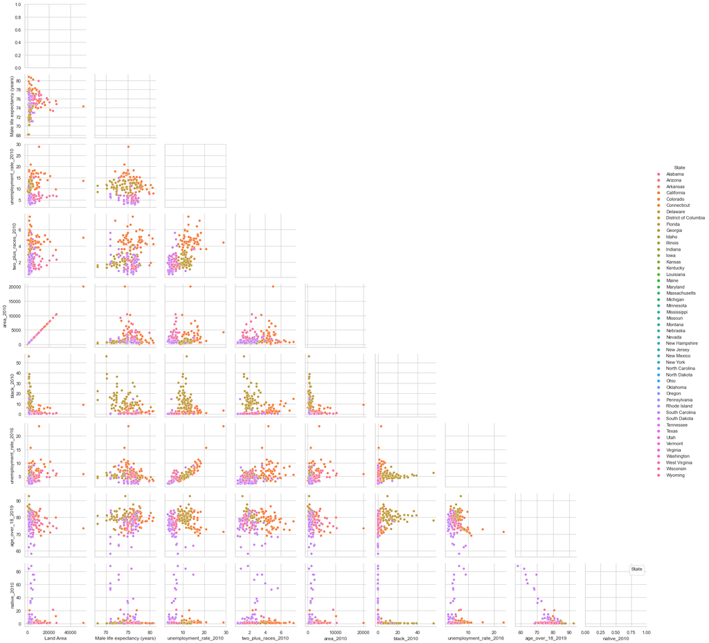

```python
sec_b_full = pd.concat([section_b_df_for_scaling,state], axis = 1)
plt.figure(figsize=(10, 10))
g = sns.PairGrid(sec_b_full, hue="State",corner=True)
g.map_offdiag(sns.scatterplot)
g.add_legend()
plt.legend(title='State', loc='upper right', labels=['California','Florida','South Dakota','Wyoming'])
```

#### Good separators features

As we can see native_2019 separate South dakota from the other states(it has a much higher value).  
unemployment_rate_2010 with male life expectancy separate the states to 3 groups(South Dakota and Wyoming vs California vs Florida).  
two_plus_races_2010 separate California from the other states, also black_2010 separate Florida from the other  
states.

#### Bad separators features

Land area, area2010, unemployment_rate_2016 and age over 18 2019.

#### Goodness of the clusters by silhouette coefficient

##### Explanation of the method

Our goal is that in a well-formed set of clusters are as follows:  
-The observations within a cluster to be as close as possible. This is referred to as Cohesion.  
-The observations from two clusters should be far from each other. This is referred to as Separation.  
We can evaluate those by using Silhouette coefficient,  
which is a method that uses the concept of both cohesion and separation.  
The calculation goes as follows:  
For each point i in a cluster j:

1. We calculate the distance of the point i from all the points in j and find the average, this is called $\large a_i$  
   of point i(our cohesion measurement).
2. For another cluster k we calculate the distance of the point i from all the points in k and find the average,  
   we do it for each other cluster beside k, the minimum of all those averages distances is chosen and called  
   $\large b_i$(our separation measurement).
3. Then Silhouette coefficient for the point i is:  
   $\large S_i = (b_i - a_i)/max(a_i, b_i).$

For a cluster the Silhouette coefficient needs to be calculated for all the points, the average is taken.  
The value lies between -1 and 1, higher the value better is the cluster.  
For more explanation, example of Silhouette coefficient and other evaluation methods [click here](https://towardsdatascience.com/are-the-clusters-good-1567de6a9524).

```python
#calculate and return the euclidean distance of 2 data points
def euclidean_distance(x,y):
    dist_arr = []#array for storing squared distance  in each dimension
    for feature in x.columns:
        if feature != 'State':
            #squared distance in specific dimension
           dist_arr.append(((y[feature] - x[feature])**2))
    #summing the squared distances and apply square root
    return np.sqrt(np.sum(dist_arr))
```

```python
#calculate distances of specific point in a cluster from all the other points in the same cluster
# or other cluster. then calculate and return the average of those distances
def distance_within_or_outside(point_i,cluster):
    euc_dist_arr = []#array for storing euclidean distance  of point_i from all other points in the same cluster, or another one
    for i,point in cluster.iterrows():
        #calculating the euclidean distance of point_i and another point
        dist = euclidean_distance(point_i,point)
        #prevent from adding the distance from itself
        if dist != 0:
            euc_dist_arr.append(dist)
    #calculating the average distance
    return np.sum(euc_dist_arr)/(len(euc_dist_arr))
```

```python
#calculate the average distance of specific point from all the other clusters and return the minimum(bi)
def calc_bi(point_i,clusters):
    min_bi = float('inf')
    for cluster in clusters:
        bi = distance_within_or_outside(point_i,cluster)
        if bi < min_bi:
            min_bi = bi
    return min_bi
```

```python
#calucate Silhouette coefficient of specific point i
def silhouette_coefficient_point_i(a_i, b_i):
    return (b_i - a_i)/np.maximum(a_i, b_i)
```

```python
#calucate the average Silhouette coefficient of a specific cluster
def silhouette_coefficient(df,cluster_i,clusters):
    #storing the ai values(cohesion) of each sample in cluster i
    ai_array = []
    #storing the bi values(separation)of  each sample in cluster i
    bi_array = []
    #storing the silhouette coefficients (separation+cohesion)of  each sample in cluster i
    silhouette_coefficients_array = []
    #calculate ai and bi for cluster_i samples
    for point_i in cluster_i.index:
        #calculate bi for cluster_i samples
        bi_array.append(calc_bi(df.iloc[point_i:point_i+1],clusters))
        #calculate ai for cluster_i samples
        ai_array.append(distance_within_or_outside(df.iloc[point_i:point_i+1],cluster_i))

    #calculate Silhouette coefficient for cluster_i samples
    for i in range(0,len(ai_array)):
        silhouette_coefficients_array.append(silhouette_coefficient_point_i(ai_array[i], bi_array[i]))
    #calucate the average Silhouette coefficient of  cluster_i
    return np.mean(silhouette_coefficients_array)
```

#### T_SNE Silhouette coefficients

```python
#Silhouette coefficients for T_SNE
#Silhouette coefficient of California
s_cal = silhouette_coefficient(X_embedded,X_embedded.loc[X_embedded['State']=='California'],[X_embedded.loc[X_embedded['State']=='Florida'],X_embedded.loc[X_embedded['State']=='South Dakota'],X_embedded.loc[X_embedded['State']=='Wyoming']])

#Silhouette coefficient of Florida
s_flo = silhouette_coefficient(X_embedded,X_embedded.loc[X_embedded['State']=='Florida'],[X_embedded.loc[X_embedded['State']=='California'],X_embedded.loc[X_embedded['State']=='South Dakota'],X_embedded.loc[X_embedded['State']=='Wyoming']])

#Silhouette coefficient of South Dakota
s_sd = silhouette_coefficient(X_embedded,X_embedded.loc[X_embedded['State']=='South Dakota'],[X_embedded.loc[X_embedded['State']=='California'],X_embedded.loc[X_embedded['State']=='Florida'],X_embedded.loc[X_embedded['State']=='Wyoming']])

#Silhouette coefficient of Wyoming
s_wyo = silhouette_coefficient(X_embedded,X_embedded.loc[X_embedded['State']=='Wyoming'],[X_embedded.loc[X_embedded['State']=='California'],X_embedded.loc[X_embedded['State']=='Florida'],X_embedded.loc[X_embedded['State']=='South Dakota']])
```

```python
df = pd.DataFrame([s_cal, s_flo, s_sd, s_wyo, (s_cal+s_wyo+s_flo+s_sd)/4]).T
df = df.rename(index={0: 'T_SNE Silhouette coefficients:'}, columns={0: 'California', 1: 'Florida', 2: 'South Dakota', 3: 'Wyoming', 4: 'Average'})
df
```

|  | California | Florida | South Dakota | Wyoming | Average |
| --- | --- | --- | --- | --- | --- |
| T_SNE Silhouette coefficients: | 0.457624 | 0.471608 | 0.254554 | 0.582548 | 0.441584 |

#### PCA Silhouette coefficients

```python
#Silhouette coefficients for PCA
#Silhouette coefficient of California
s_cal = silhouette_coefficient(X_pca,X_pca.loc[X_pca['State']=='California'],[X_pca.loc[X_pca['State']=='Florida'],X_pca.loc[X_pca['State']=='South Dakota'],X_pca.loc[X_pca['State']=='Wyoming']])

#Silhouette coefficient of Florida
s_flo = silhouette_coefficient(X_pca,X_pca.loc[X_pca['State']=='Florida'],[X_pca.loc[X_pca['State']=='California'],X_pca.loc[X_pca['State']=='South Dakota'],X_pca.loc[X_pca['State']=='Wyoming']])

#Silhouette coefficient of South Dakota
s_sd = silhouette_coefficient(X_pca,X_pca.loc[X_pca['State']=='South Dakota'],[X_pca.loc[X_pca['State']=='California'],X_pca.loc[X_pca['State']=='Florida'],X_pca.loc[X_pca['State']=='Wyoming']])

#Silhouette coefficient of Wyoming
s_wyo = silhouette_coefficient(X_pca,X_pca.loc[X_pca['State']=='Wyoming'],[X_pca.loc[X_pca['State']=='California'],X_pca.loc[X_pca['State']=='Florida'],X_pca.loc[X_pca['State']=='South Dakota']])
```

```python
df = pd.DataFrame([s_cal, s_flo, s_sd, s_wyo, (s_cal+s_wyo+s_flo+s_sd)/4]).T
df = df.rename(index={0: 'PCA Silhouette coefficients:'}, columns={0: 'California', 1: 'Florida', 2: 'South Dakota', 3: 'Wyoming', 4: 'Average'})
df
```

|  | California | Florida | South Dakota | Wyoming | Average |
| --- | --- | --- | --- | --- | --- |
| PCA Silhouette coefficients: | 0.080479 | 0.349108 | 0.186045 | 0.260510 | 0.219036 |

#### Summery

As we can see by all metrics(each cluster's Silhouette coefficient, and the average)the states clustering by  
T-SNE dimensionality reduction is better.

### Section C - (Regression) house vote turnouts predictions

### Task

predict voter turnout by state for the years 2010 and 2012 for the house elections.

### Checking different Models

### Gradiant Boost

```python
def g_boost(train_x, train_y, test_x, test_y):
    # define model
    gb = GradientBoostingRegressor(random_state=RSEED)

    # define parameter grid
    parameters_grid = {
        'learning_rate': [0.5,0.75, 1, 1.5],
        'n_estimators': [30, 60, 100,150,200],
    }

    # define grid search
    grid_search = GridSearchCV(estimator=gb, param_grid=parameters_grid, cv=10)

    start_time = time.time()
    # fit estimator
    grid_search.fit(train_x, train_y)
    print("sklearn gradiant boost fit time %s seconds ---" % (time.time() - start_time))

    # get best estimator
    best = grid_search.best_estimator_

    # print best parameters
    print(pd.DataFrame.from_dict(grid_search.best_params_, orient='index', columns=['Selected Value']).T)

    # predict
    y_pred = best.predict(test_x)

    MSE = round(mean_squared_error(test_y, y_pred), 3)
    R2 = r2_score(test_y, y_pred)
    pd.set_option('display.float_format', lambda x: '%.3f' % x)
    df = pd.DataFrame([MSE, R2]).T
    df = df.rename(index={0: 'Gradiant Boost Regressor'}, columns={0: 'MSE', 1: 'R^2'})
    print(df)
    return MSE, R2, grid_search, y_pred
```

```python
gradient_MSE, gradient_R2, gradient_gridsearch, gradient_predicted_vals= g_boost(sec_c_trainX, sec_c_trainY, sec_c_testX, sec_c_testY)
```

```
sklearn gradiant boost fit time 11.760299682617188 seconds ---
                learning_rate  n_estimators
Selected Value       0.500000     60.000000
                           MSE   R^2
Gradiant Boost Regressor 0.002 0.817
```

Now we will print a plot that show the diffrences between the real and predicted values

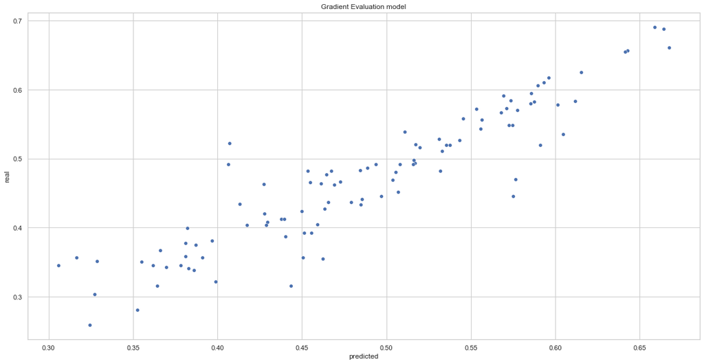

```python
reals_vals = {}
reals_vals['real'] =  sec_c_testY.values

predicted_vals = {}
predicted_vals['predicted'] = gradient_predicted_vals


real_df = pd.DataFrame(reals_vals)
pred_df = pd.DataFrame(predicted_vals)

evaluation_reg_df = pd.concat([real_df,pred_df], axis=1 )

plt.figure(figsize=(20, 10))
sns.scatterplot(data=evaluation_reg_df, x="predicted", y="real").set(title = 'Gradient Evaluation model')
plt.show()
```

Now we will print a plot that show the diffrences between the real and predicted values  
for the 4 states

```python
dict = {}
dict['predictions'] = gradient_predicted_vals
```

```python
pred_df = pd.DataFrame.from_dict(dict)
```

```python
sec_c_testY.index = sec_c_testX.index
pred_df.index = sec_c_testX.index
four_states_resault_df = pd.concat([sec_c_testX,sec_c_testY, pred_df],axis=1)
```

```python
four_states_resault_df = four_states_resault_df.loc[(four_states_resault_df['state_CALIFORNIA']==1)|(four_states_resault_df['state_FLORIDA']==1)|(four_states_resault_df['state_SOUTH DAKOTA']==1)|(four_states_resault_df['state_WYOMING']==1)]
```

```python
four_states_resault_2010_df = four_states_resault_df.loc[four_states_resault_df['year']==2010]
four_states_resault_2012_df = four_states_resault_df.loc[four_states_resault_df['year']==2012]
```

#### Compering between real values 2010 to predicted values

```python
reals_vals = {}
reals_vals['vals'] =  four_states_resault_2010_df['vote_turnouts'].values
reals_vals['type'] = 'real'

predicted_vals = {}
predicted_vals['type'] = 'predicted'
predicted_vals['vals'] = four_states_resault_2010_df['predictions'].values
predicted_vals['states'] = ['California','Florida','SOUTH DAKOTA','WYOMING']

states_vals = {}
states_vals['states'] = ['California','Florida','SOUTH DAKOTA','WYOMING']

real_df = pd.DataFrame(reals_vals)
pred_df = pd.DataFrame(predicted_vals)
states_df = pd.DataFrame(states_vals)

evaluation_reg_df = pd.concat([real_df,states_df], axis=1 )
evaluation_reg_df = evaluation_reg_df.append(pred_df)
```

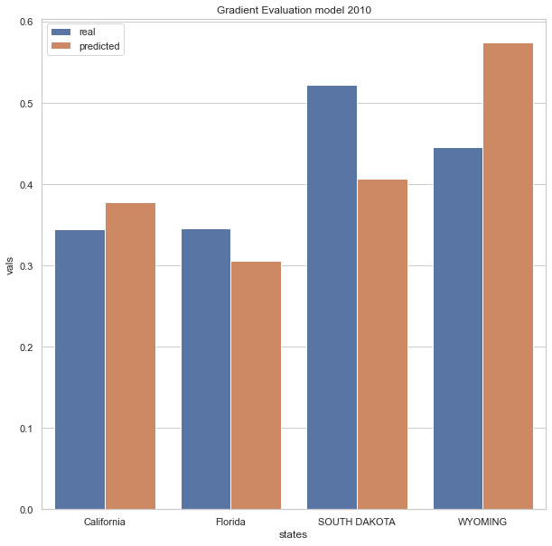

```python
plt.figure(figsize=(10, 10))
ax = sns.barplot(x="states", y="vals", hue="type", data=evaluation_reg_df).set(title = 'Gradient Evaluation model 2010')
plt.legend(loc='upper left')
```

#### Compering between real values 2012 to predicted values

```python
reals_vals = {}
reals_vals['vals'] =  four_states_resault_2012_df['vote_turnouts'].values
reals_vals['type'] = 'real'

predicted_vals = {}
predicted_vals['type'] = 'predicted'
predicted_vals['vals'] = four_states_resault_2012_df['predictions'].values
predicted_vals['states'] = ['California','Florida','SOUTH DAKOTA','WYOMING']

states_vals = {}
states_vals['states'] = ['California','Florida','SOUTH DAKOTA','WYOMING']

real_df = pd.DataFrame(reals_vals)
pred_df = pd.DataFrame(predicted_vals)
states_df = pd.DataFrame(states_vals)

evaluation_reg_df = pd.concat([real_df,states_df], axis=1 )
evaluation_reg_df = evaluation_reg_df.append(pred_df)

evaluation_reg_df
```

|  | vals | type | states |
| --- | --- | --- | --- |
| 0 | 0.428 | real | California |
| 1 | 0.494 | real | Florida |
| 2 | 0.578 | real | SOUTH DAKOTA |
| 3 | 0.572 | real | WYOMING |
| 0 | 0.463 | predicted | California |
| 1 | 0.517 | predicted | Florida |
| 2 | 0.602 | predicted | SOUTH DAKOTA |
| 3 | 0.553 | predicted | WYOMING |

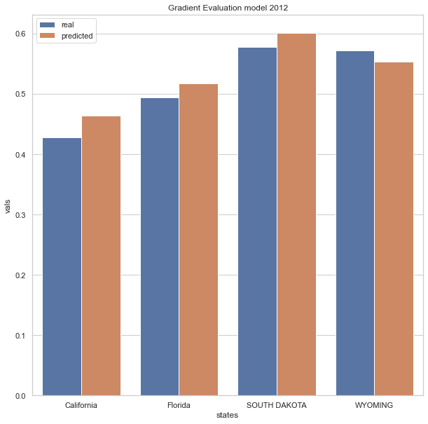

```python
plt.figure(figsize=(10, 10))
ax = sns.barplot(x="states", y="vals", hue="type", data=evaluation_reg_df).set(title = 'Gradient Evaluation model 2012')
plt.legend(loc='upper left')
```

##### features importance

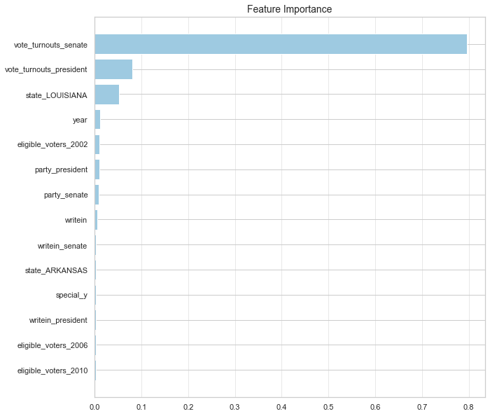

```python
gradient_imp = feat_importance(gradient_gridsearch, sec_c_trainX, sec_c_trainY)
```

### Random Forest

```python
def r_forest(train_x, train_y, test_x, test_y):
    rf = RandomForestRegressor(random_state=RSEED)

    # define parameter grid
    parameters_grid = {
        'max_depth': [5,8],
        'min_samples_split': [3,5,10,15, 30],
        'n_estimators': [20, 50,70]
    }

    # define grid search
    grid_search = GridSearchCV(estimator=rf, param_grid=parameters_grid, cv=10)

    # fit estimator
    start_time = time.time()
    grid_search.fit(train_x, train_y)
    print("sklearn gradiant boost fit time %s seconds ---" % (time.time() - start_time))

    # get best estimator
    best = grid_search.best_estimator_

    # print best parameters
    print(pd.DataFrame.from_dict(grid_search.best_params_, orient='index', columns=['Selected Value']).T)

    # predict
    y_pred = best.predict(test_x)

    MSE = round(mean_squared_error(test_y, y_pred), 3)
    R2 = r2_score(test_y, y_pred)
    pd.set_option('display.float_format', lambda x: '%.3f' % x)
    df = pd.DataFrame([MSE, R2]).T
    df = df.rename(index={0: 'Random Forest Regressor'}, columns={0: 'MSE', 1: 'R^2'})
    print(df)
    return MSE, R2, grid_search, y_pred
```

```python
forset_MSE, forset_R2, forset_gridsearch ,random_forest_predicted_vals= r_forest(sec_c_trainX, sec_c_trainY, sec_c_testX, sec_c_testY)
```

```
sklearn gradiant boost fit time 16.608664989471436 seconds ---
                max_depth  min_samples_split  n_estimators
Selected Value          8                  3            70
                          MSE   R^2
Random Forest Regressor 0.002 0.803
```

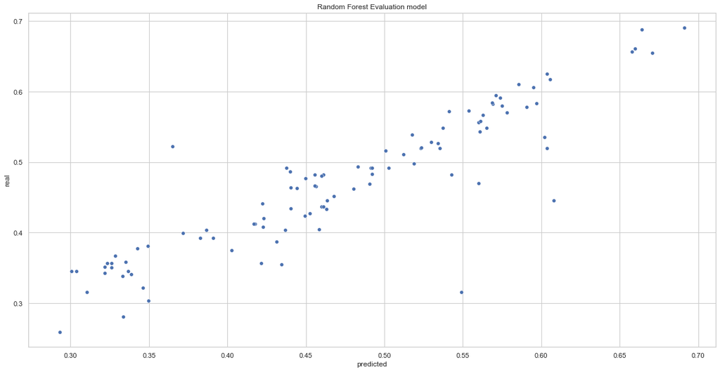

```python
reals_vals = {}
reals_vals['real'] =  sec_c_testY.values

predicted_vals = {}
predicted_vals['predicted'] = random_forest_predicted_vals


real_df = pd.DataFrame(reals_vals)
pred_df = pd.DataFrame(predicted_vals)

evaluation_reg_df = pd.concat([real_df,pred_df], axis=1 )

plt.figure(figsize=(20, 10))
sns.scatterplot(data=evaluation_reg_df, x="predicted", y="real").set(title = 'Random Forest Evaluation model')
plt.show()
```

Now we will print a plot that show the diffrences between the real and predicted values  
for the 4 states

```python
dict = {}
dict['predictions'] = random_forest_predicted_vals
pred_df = pd.DataFrame.from_dict(dict)
pred_df
sec_c_testY.index = sec_c_testX.index
pred_df.index = sec_c_testX.index
four_states_resault_df = pd.concat([sec_c_testX, sec_c_testY, pred_df], axis=1)
```

```python
four_states_resault_df = four_states_resault_df.loc[(four_states_resault_df['state_CALIFORNIA']==1)|(four_states_resault_df['state_FLORIDA']==1)|(four_states_resault_df['state_SOUTH DAKOTA']==1)|(four_states_resault_df['state_WYOMING']==1)]
```

```python
four_states_resault_2010_df = four_states_resault_df.loc[four_states_resault_df['year'] == 2010]
four_states_resault_2012_df = four_states_resault_df.loc[four_states_resault_df['year'] == 2012]
```

```python
reals_vals = {}
reals_vals['vals'] =  four_states_resault_2010_df['vote_turnouts'].values
reals_vals['type'] = 'real'

predicted_vals = {}
predicted_vals['type'] = 'predicted'
predicted_vals['vals'] = four_states_resault_2010_df['predictions'].values
predicted_vals['states'] = ['California','Florida','SOUTH DAKOTA','WYOMING']

states_vals = {}
states_vals['states'] = ['California','Florida','SOUTH DAKOTA','WYOMING']

real_df = pd.DataFrame(reals_vals)
pred_df = pd.DataFrame(predicted_vals)
states_df = pd.DataFrame(states_vals)

evaluation_reg_df = pd.concat([real_df,states_df], axis=1 )
evaluation_reg_df = evaluation_reg_df.append(pred_df)
```

#### Compering between real values 2010 to predicted values

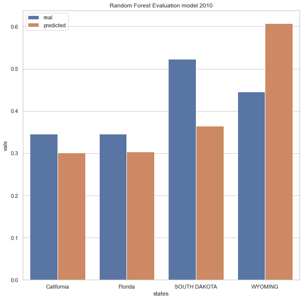

```python
plt.figure(figsize=(10, 10))
ax = sns.barplot(x="states", y="vals", hue="type", data=evaluation_reg_df).set(title = 'Random Forest Evaluation model 2010')
plt.legend(loc='upper left')
```

```python
reals_vals = {}
reals_vals['vals'] =  four_states_resault_2010_df['vote_turnouts'].values
reals_vals['type'] = 'real'

predicted_vals = {}
predicted_vals['type'] = 'predicted'
predicted_vals['vals'] = four_states_resault_2010_df['predictions'].values
predicted_vals['states'] = ['California','Florida','SOUTH DAKOTA','WYOMING']

states_vals = {}
states_vals['states'] = ['California','Florida','SOUTH DAKOTA','WYOMING']

real_df = pd.DataFrame(reals_vals)
pred_df = pd.DataFrame(predicted_vals)
states_df = pd.DataFrame(states_vals)

evaluation_reg_df = pd.concat([real_df,states_df], axis=1 )
evaluation_reg_df = evaluation_reg_df.append(pred_df)
```

```python
reals_vals = {}
reals_vals['vals'] =  four_states_resault_2012_df['vote_turnouts'].values
reals_vals['type'] = 'real'

predicted_vals = {}
predicted_vals['type'] = 'predicted'
predicted_vals['vals'] = four_states_resault_2012_df['predictions'].values
predicted_vals['states'] = ['California','Florida','SOUTH DAKOTA','WYOMING']

states_vals = {}
states_vals['states'] = ['California','Florida','SOUTH DAKOTA','WYOMING']

real_df = pd.DataFrame(reals_vals)
pred_df = pd.DataFrame(predicted_vals)
states_df = pd.DataFrame(states_vals)

evaluation_reg_df = pd.concat([real_df,states_df], axis=1 )
evaluation_reg_df = evaluation_reg_df.append(pred_df)
```

#### Compering between real values 2012 to predicted values

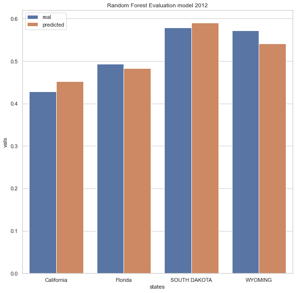

```python
plt.figure(figsize=(10, 10))
ax = sns.barplot(x="states", y="vals", hue="type", data=evaluation_reg_df).set(title = 'Random Forest Evaluation model 2012')
plt.legend(loc='upper left')
```

##### features importance

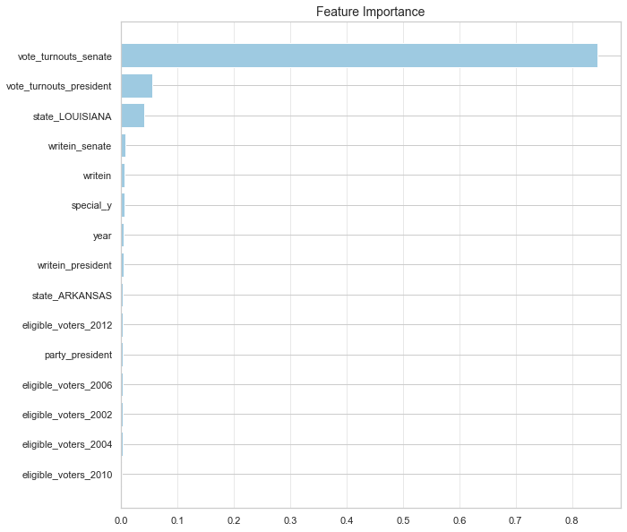

```python
rand_imp = feat_importance(forset_gridsearch, sec_c_trainX, sec_c_trainY)
```

### Adaboot

```python
def ada_boost(train_x, train_y, test_x, test_y):
    # define model
    ab = AdaBoostRegressor(random_state=RSEED)

    # define parameter grid
    parameters_grid = {
        'n_estimators': [50,70]
    }

    # define grid search
    grid_search = GridSearchCV(estimator=ab, param_grid=parameters_grid, cv=10)
    # fit estimator
    start_time = time.time()
    grid_search.fit(train_x, train_y)
    print("sklearn Ada boost fit time %s seconds ---" % (time.time() - start_time))

    # get best estimator
    best = grid_search.best_estimator_

    # print best parameters
    print(pd.DataFrame.from_dict(grid_search.best_params_, orient='index', columns=['Selected Value']).T)

    # predict
    y_pred = best.predict(test_x)


    MSE = round(mean_squared_error(test_y,  y_pred), 3)
    R2 = r2_score(test_y,   y_pred)
    pd.set_option('display.float_format', lambda x: '%.3f' % x)
    df = pd.DataFrame([MSE, R2]).T
    df = df.rename(index={0: 'AdaBoost Regressor'}, columns={0: 'MSE', 1: 'R^2'})
    print(df)
    return MSE, R2, grid_search,   y_pred
```

```python
ada_MSE, ada_R2, ada_gridsearch , Adaboost_predicted_vals= ada_boost(sec_c_trainX, sec_c_trainY, sec_c_testX, sec_c_testY)
```

```
sklearn Ada boost fit time 1.404961109161377 seconds ---
                n_estimators
Selected Value            50
                     MSE   R^2
AdaBoost Regressor 0.002 0.806
```

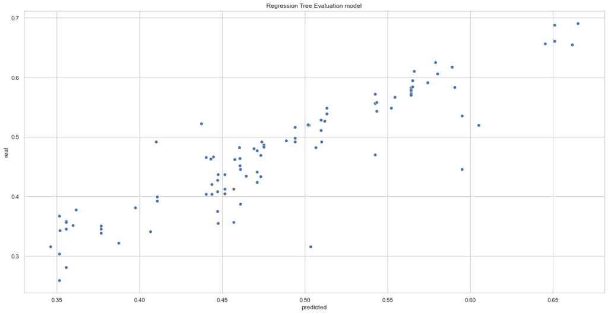

```python
reals_vals = {}
reals_vals['real'] =  sec_c_testY.values

predicted_vals = {}
predicted_vals['predicted'] = Adaboost_predicted_vals


real_df = pd.DataFrame(reals_vals)
pred_df = pd.DataFrame(predicted_vals)

evaluation_reg_df = pd.concat([real_df,pred_df], axis=1 )

plt.figure(figsize=(20, 10))
sns.scatterplot(data=evaluation_reg_df, x="predicted", y="real").set(title = 'Regression Tree Evaluation model')
plt.show()
```

Now we will print a plot that show the diffrences between the real and predicted values  
for the 4 states

```python
dict = {}
dict['predictions'] = Adaboost_predicted_vals
pred_df = pd.DataFrame.from_dict(dict)
pred_df
sec_c_testY.index = sec_c_testX.index
pred_df.index = sec_c_testX.index
four_states_resault_df = pd.concat([sec_c_testX, sec_c_testY, pred_df], axis=1)
four_states_resault_df = four_states_resault_df.loc[
    (four_states_resault_df['state_CALIFORNIA'] == 1) | (four_states_resault_df['state_FLORIDA'] == 1) | (
                four_states_resault_df['state_SOUTH DAKOTA'] == 1) | (four_states_resault_df['state_WYOMING'] == 1)]
four_states_resault_2010_df = four_states_resault_df.loc[four_states_resault_df['year'] == 2010]
four_states_resault_2012_df = four_states_resault_df.loc[four_states_resault_df['year'] == 2012]
```

#### Compering between real values 2010 to predicted values

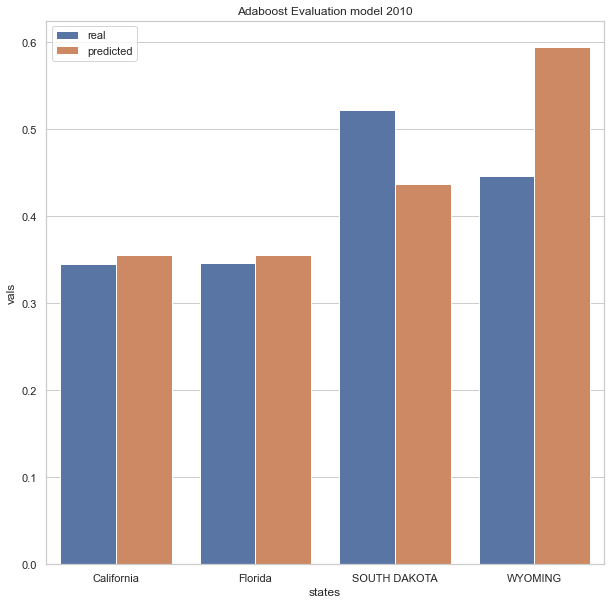

```python
reals_vals = {}
reals_vals['vals'] = four_states_resault_2010_df['vote_turnouts'].values
reals_vals['type'] = 'real'

predicted_vals = {}
predicted_vals['type'] = 'predicted'
predicted_vals['vals'] = four_states_resault_2010_df['predictions'].values
predicted_vals['states'] = ['California', 'Florida', 'SOUTH DAKOTA', 'WYOMING']

states_vals = {}
states_vals['states'] = ['California', 'Florida', 'SOUTH DAKOTA', 'WYOMING']

real_df = pd.DataFrame(reals_vals)
pred_df = pd.DataFrame(predicted_vals)
states_df = pd.DataFrame(states_vals)

evaluation_reg_df = pd.concat([real_df, states_df], axis=1)
evaluation_reg_df = evaluation_reg_df.append(pred_df)
plt.figure(figsize=(10, 10))
ax = sns.barplot(x="states", y="vals", hue="type", data=evaluation_reg_df).set(
    title='Adaboost Evaluation model 2010')
plt.legend(loc='upper left')
```

#### Compering between real values 2012 to predicted values

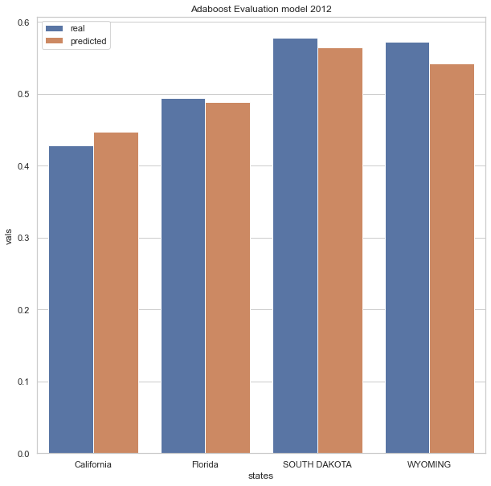

```python
reals_vals = {}
reals_vals['vals'] = four_states_resault_2012_df['vote_turnouts'].values
reals_vals['type'] = 'real'

predicted_vals = {}
predicted_vals['type'] = 'predicted'
predicted_vals['vals'] = four_states_resault_2012_df['predictions'].values
predicted_vals['states'] = ['California', 'Florida', 'SOUTH DAKOTA', 'WYOMING']

states_vals = {}
states_vals['states'] = ['California', 'Florida', 'SOUTH DAKOTA', 'WYOMING']

real_df = pd.DataFrame(reals_vals)
pred_df = pd.DataFrame(predicted_vals)
states_df = pd.DataFrame(states_vals)

evaluation_reg_df = pd.concat([real_df, states_df], axis=1)
evaluation_reg_df = evaluation_reg_df.append(pred_df)
plt.figure(figsize=(10, 10))
ax = sns.barplot(x="states", y="vals", hue="type", data=evaluation_reg_df).set(
    title='Adaboost Evaluation model 2012')
plt.legend(loc='upper left')
```

##### Features importance

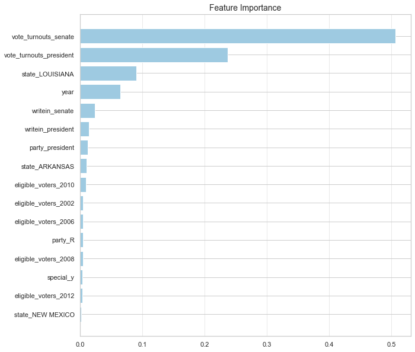

```python
ada_imp = feat_importance(ada_gridsearch, sec_c_trainX, sec_c_trainY)
```

### Comparing models results

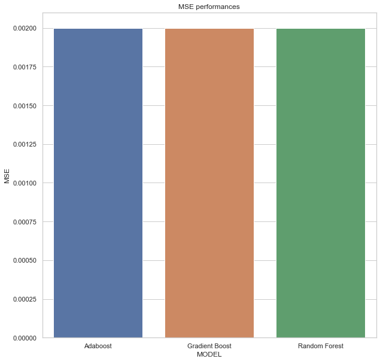

```python
mse_dict = {"MSE": [ada_MSE, gradient_MSE, forset_MSE],
            "MODEL": ["Adaboost", "Gradient Boost", "Random Forest"]}
mse_df = pd.DataFrame(mse_dict)
# visualize the target variable
plt.figure(figsize=(10, 10))
ax = sns.barplot(x="MODEL", y="MSE", data=mse_df).set(
    title='MSE performances')
plt.show()
```

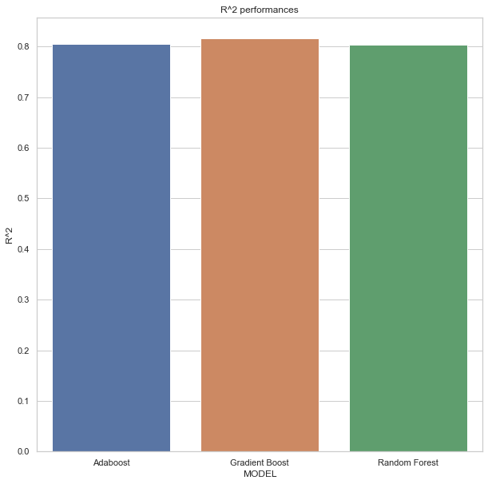

```python
R2_dict = {"R^2": [ada_R2, gradient_R2, forset_R2],
           "MODEL": ["Adaboost", "Gradient Boost", "Random Forest"]}
R2_df = pd.DataFrame(R2_dict)
# visualize the target variable
plt.figure(figsize=(10, 10))
ax = sns.barplot(x="MODEL", y="R^2", data=R2_df).set(
    title='R^2 performances')
plt.show()
```

#### Improve prediction for two states

**Task:**  
Ranking the states by how well your model predicted turnout. Specifically,  
we will specify the 5 states that the turnout estimate was least successful.  
Then, we will make modifications to your model and features so that at least 2 of  
the states that were in the bottom 5 will be ranked in the within the  
top 25 for prediction rate.

The Dataset

```python
sec_c_improvment
```

|  | year | state | special_x | party | writein | eligible_voters_2002 | eligible_voters_2004 | eligible_voters_2006 | eligible_voters_2008 | eligible_voters_2010 | eligible_voters_2012 | vote_turnouts | writein_president | party_president | vote_turnouts_president | special_y | writein_senate | party_senate | vote_turnouts_senate |
| --- | --- | --- | --- | --- | --- | --- | --- | --- | --- | --- | --- | --- | --- | --- | --- | --- | --- | --- | --- |
| 0 | 2002 | ALABAMA | 0.000 | R | 0.280 | 3407064.949 | 3421131.668 | 3436141.794 | 3452116.233 | 3647015.426 | 3673062.870 | 0.372 | 0.091 | 0.000 | 0.557 | 0.000 | 0.250 | 0.000 | 0.397 |
| 1 | 2004 | ALABAMA | 0.000 | R | 0.350 | 3407064.949 | 3421131.668 | 3436141.794 | 3452116.233 | 3647015.426 | 3673062.870 | 0.524 | 0.250 | 0.000 | 0.551 | 0.000 | 0.333 | 0.000 | 0.538 |
| 2 | 2006 | ALABAMA | 0.000 | R | 0.368 | 3407064.949 | 3421131.668 | 3436141.794 | 3452116.233 | 3647015.426 | 3673062.870 | 0.332 | 0.085 | 0.000 | 0.557 | 0.000 | 0.158 | 0.290 | 0.486 |
| 3 | 2008 | ALABAMA | 0.000 | R | 0.389 | 3407064.949 | 3421131.668 | 3436141.794 | 3452116.233 | 3647015.426 | 3673062.870 | 0.537 | 0.250 | 0.000 | 0.608 | 0.000 | 0.333 | 0.000 | 0.597 |
| 4 | 2010 | ALABAMA | 0.000 | R | 0.368 | 3407064.949 | 3421131.668 | 3436141.794 | 3452116.233 | 3647015.426 | 3673062.870 | 0.375 | 0.108 | 0.000 | 0.558 | 0.000 | 0.333 | 0.000 | 0.407 |
| ... | ... | ... | ... | ... | ... | ... | ... | ... | ... | ... | ... | ... | ... | ... | ... | ... | ... | ... | ... |
| 295 | 2004 | WYOMING | 0.000 | R | 0.200 | 378569.469 | 381666.983 | 384835.552 | 388076.323 | 428220.153 | 438107.792 | 0.627 | 0.167 | 0.000 | 0.639 | 0.345 | 0.216 | 0.000 | 1.047 |
| 296 | 2006 | WYOMING | 0.000 | R | 0.167 | 378569.469 | 381666.983 | 384835.552 | 388076.323 | 428220.153 | 438107.792 | 0.510 | 0.162 | 0.088 | 0.632 | 0.000 | 0.200 | 0.000 | 0.510 |
| 297 | 2008 | WYOMING | 0.000 | R | 0.200 | 378569.469 | 381666.983 | 384835.552 | 388076.323 | 428220.153 | 438107.792 | 0.643 | 0.167 | 0.000 | 0.657 | 0.500 | 0.250 | 0.000 | 1.287 |
| 298 | 2010 | WYOMING | 0.000 | R | 0.167 | 378569.469 | 381666.983 | 384835.552 | 388076.323 | 428220.153 | 438107.792 | 0.446 | 0.164 | 0.000 | 0.627 | 0.093 | 0.130 | 0.000 | 0.649 |
| 299 | 2012 | WYOMING | 0.000 | R | 0.125 | 378569.469 | 381666.983 | 384835.552 | 388076.323 | 428220.153 | 438107.792 | 0.572 | 0.143 | 0.000 | 0.572 | 0.000 | 0.167 | 0.000 | 0.572 |

300 rows × 19 columns

Adding predicted values column

```python
sec_c_test_improvement = sec_c_improvment.loc[sec_c_improvment['year']>=2010]
#Add predicted values column
sec_c_test_improvement['predicted vals'] = Adaboost_predicted_vals
```

Grouping by states and calculating SSR.

```python
#grouping counties by state
sec_c_improvment_groupedby = sec_c_test_improvement.groupby(['state'])

sec_c_improvment_after_arrange = pd.DataFrame()
for key,item in sec_c_improvment_groupedby:
    state_samples = item
    state_samples = state_samples.assign(SSR=lambda x: (x['predicted vals'] - x['vote_turnouts'])**2)
    state_samples['SSR'] = np.sum(state_samples['SSR'])
    sec_c_improvment_after_arrange = sec_c_improvment_after_arrange.append(state_samples.iloc[0:1,:])
```

```python
c_improvment_after_arrange = sec_c_improvment_after_arrange[['state', 'SSR']]
```

Printing results:

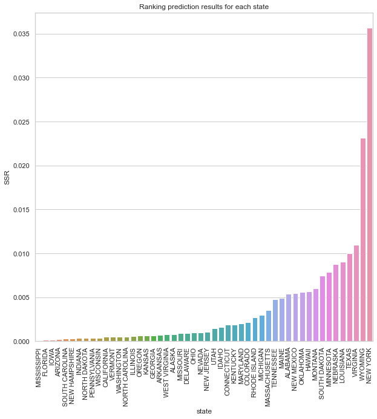

```python
# visualize the target variable
plt.figure(figsize=(10, 10))
ax = sns.barplot(x="state", y="SSR", data=c_improvment_after_arrange.sort_values(ascending=True, by=['SSR'] )).set(
    title='Ranking prediction results for each state')
plt.xticks(rotation=90)
plt.show()
```

```python
c_improvment_after_arrange.sort_values(ascending=False, by=['SSR'] )
```

|  | state | SSR |
| --- | --- | --- |
| 190 | NEW YORK | 0.036 |
| 298 | WYOMING | 0.023 |
| 274 | VIRGINIA | 0.011 |
| 256 | TEXAS | 0.010 |
| 106 | LOUISIANA | 0.009 |
| 160 | NEBRASKA | 0.009 |
| 136 | MINNESOTA | 0.008 |
| 244 | SOUTH DAKOTA | 0.007 |
| 154 | MONTANA | 0.006 |
| 64 | HAWAII | 0.006 |
| 214 | OKLAHOMA | 0.006 |
| 184 | NEW MEXICO | 0.005 |
| 4 | ALABAMA | 0.005 |
| 112 | MAINE | 0.005 |
| 250 | TENNESSEE | 0.005 |
| 124 | MASSACHUSETTS | 0.004 |
| 130 | MICHIGAN | 0.003 |
| 232 | RHODE ISLAND | 0.003 |
| 34 | COLORADO | 0.002 |
| 118 | MARYLAND | 0.002 |
| 100 | KENTUCKY | 0.002 |
| 40 | CONNECTICUT | 0.002 |
| 70 | IDAHO | 0.002 |
| 262 | UTAH | 0.001 |
| 178 | NEW JERSEY | 0.001 |
| 166 | NEVADA | 0.001 |
| 208 | OHIO | 0.001 |
| 46 | DELAWARE | 0.001 |
| 148 | MISSOURI | 0.001 |
| 10 | ALASKA | 0.001 |
| 286 | WEST VIRGINIA | 0.001 |
| 22 | ARKANSAS | 0.001 |
| 58 | GEORGIA | 0.001 |
| 94 | KANSAS | 0.001 |
| 220 | OREGON | 0.001 |
| 76 | ILLINOIS | 0.001 |
| 196 | NORTH CAROLINA | 0.001 |
| 280 | WASHINGTON | 0.001 |
| 268 | VERMONT | 0.000 |
| 28 | CALIFORNIA | 0.000 |
| 292 | WISCONSIN | 0.000 |
| 226 | PENNSYLVANIA | 0.000 |
| 202 | NORTH DAKOTA | 0.000 |
| 82 | INDIANA | 0.000 |
| 172 | NEW HAMPSHIRE | 0.000 |
| 238 | SOUTH CAROLINA | 0.000 |
| 16 | ARIZONA | 0.000 |
| 88 | IOWA | 0.000 |
| 52 | FLORIDA | 0.000 |
| 142 | MISSISSIPPI | 0.000 |

#### Checking for outliers in the best predictors

As we saw earlier the Senate turn vote turnouts feature has high correlation of 0.8  
with our target(House turn vote outs).  
Also, the Presidential turn vote outs has relative high correlation of 0.7 with our target.  
if there are any outliers in those features this can harm the predictions of our model.  
Therefor lets check for any outliers if there are any we will change their values to  
the 10 percentile or the 90 percentile, considering the outlier direction.

#### Vote turnouts senate

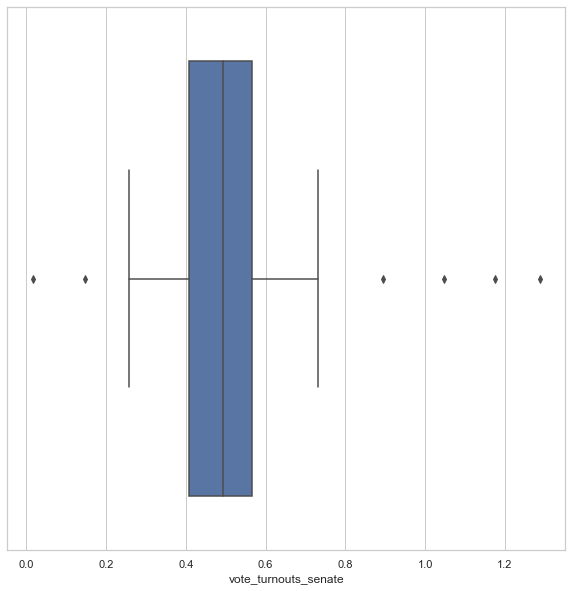

```python
plt.figure(figsize=(10, 10))
sns.set_theme(style="whitegrid")
ax = sns.boxplot(x=sec_c_improvment['vote_turnouts_senate'])
```

As we can see we have 6 outliers, lets print them.

```python
#IQR(0.75percentile - 0.25percentile)
IQR = np.percentile(sec_c_improvment['vote_turnouts_senate'],75) - np.percentile(sec_c_improvment['vote_turnouts_senate'],25)
#lower and upper bounds(any samples beyond are outliers)
upper = np.percentile(sec_c_improvment['vote_turnouts_senate'],75)+1.5*IQR
lower = np.percentile(sec_c_improvment['vote_turnouts_senate'],25)-1.5*IQR
senate_outliers = sec_c_improvment.loc[(sec_c_improvment['vote_turnouts_senate'] > upper) | (sec_c_improvment['vote_turnouts_senate'] < lower)][['year','state','vote_turnouts','vote_turnouts_senate']]
senate_outliers
```

|  | year | state | vote_turnouts | vote_turnouts_senate |
| --- | --- | --- | --- | --- |
| 57 | 2008 | GEORGIA | 0.555 | 0.894 |
| 141 | 2008 | MISSISSIPPI | 0.596 | 1.174 |
| 176 | 2006 | NEW JERSEY | 0.325 | 0.016 |
| 284 | 2006 | WEST VIRGINIA | 0.325 | 0.147 |
| 295 | 2004 | WYOMING | 0.627 | 1.047 |
| 297 | 2008 | WYOMING | 0.643 | 1.287 |

2 of the outliers are from one of the 5 worst predictions states.  
Let's change their values.

```python
#10 and 90 percentiles
tenth_percentile = np.percentile(sec_c_improvment['vote_turnouts_senate'],10)
ninetieth_percentile = np.percentile(sec_c_improvment['vote_turnouts_senate'],90)
```

```python
#changing the values
sec_c_improvment['vote_turnouts_senate'] = np.where(sec_c_improvment['vote_turnouts_senate']>ninetieth_percentile, ninetieth_percentile, sec_c_improvment['vote_turnouts_senate'])
sec_c_improvment['vote_turnouts_senate'] = np.where(sec_c_improvment['vote_turnouts_senate']<tenth_percentile, tenth_percentile, sec_c_improvment['vote_turnouts_senate'])
```

#### Vote turnouts presidential

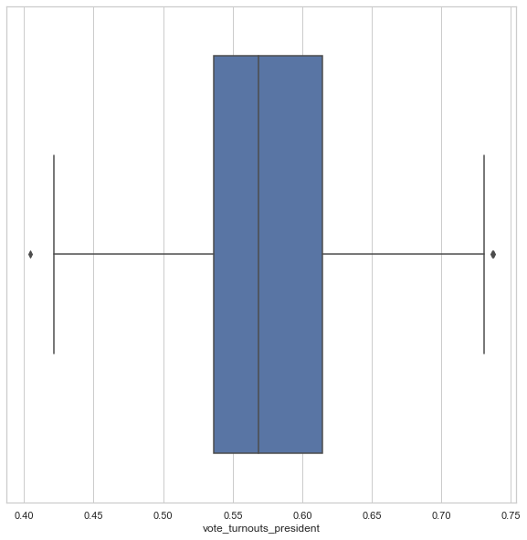

```python
plt.figure(figsize=(10, 10))
sns.set_theme(style="whitegrid")
ax = sns.boxplot(x=sec_c_improvment['vote_turnouts_president'])
```

As we can see we have outliers, lets print them.

```python
#IQR(0.75percentile - 0.25percentile)
IQR = np.percentile(sec_c_improvment['vote_turnouts_president'],75) - np.percentile(sec_c_improvment['vote_turnouts_president'],25)
#lower and upper bounds(any samples beyond are outliers)
upper = np.percentile(sec_c_improvment['vote_turnouts_president'],75)+1.5*IQR
lower = np.percentile(sec_c_improvment['vote_turnouts_president'],25)-1.5*IQR
sec_c_improvment.loc[(sec_c_improvment['vote_turnouts_president'] > upper) | (sec_c_improvment['vote_turnouts_president'] < lower)][['year','state','vote_turnouts','vote_turnouts_president']]
```

|  | year | state | vote_turnouts | vote_turnouts_president |
| --- | --- | --- | --- | --- |
| 65 | 2012 | HAWAII | 0.404 | 0.404 |
| 133 | 2004 | MINNESOTA | 0.709 | 0.737 |
| 135 | 2008 | MINNESOTA | 0.710 | 0.737 |

None are from the 5 worst predictions states, yet let's change their values.

```python
#10 and 90 percentiles
tenth_percentile = np.percentile(sec_c_improvment['vote_turnouts_president'],10)
ninetieth_percentile = np.percentile(sec_c_improvment['vote_turnouts_president'],90)
```

```python
#changing the values
sec_c_improvment['vote_turnouts_president'] = np.where(sec_c_improvment['vote_turnouts_president']>ninetieth_percentile, ninetieth_percentile, sec_c_improvment['vote_turnouts_president'])
sec_c_improvment['vote_turnouts_president'] = np.where(sec_c_improvment['vote_turnouts_president']<tenth_percentile, tenth_percentile, sec_c_improvment['vote_turnouts_president'])
```

```python
sec_c_improvment
```

|  | year | state | special_x | party | writein | eligible_voters_2002 | eligible_voters_2004 | eligible_voters_2006 | eligible_voters_2008 | eligible_voters_2010 | eligible_voters_2012 | vote_turnouts | writein_president | party_president | vote_turnouts_president | special_y | writein_senate | party_senate | vote_turnouts_senate |
| --- | --- | --- | --- | --- | --- | --- | --- | --- | --- | --- | --- | --- | --- | --- | --- | --- | --- | --- | --- |
| 0 | 2002 | ALABAMA | 0.000 | R | 0.280 | 3407064.949 | 3421131.668 | 3436141.794 | 3452116.233 | 3647015.426 | 3673062.870 | 0.372 | 0.091 | 0.000 | 0.557 | 0.000 | 0.250 | 0.000 | 0.397 |
| 1 | 2004 | ALABAMA | 0.000 | R | 0.350 | 3407064.949 | 3421131.668 | 3436141.794 | 3452116.233 | 3647015.426 | 3673062.870 | 0.524 | 0.250 | 0.000 | 0.551 | 0.000 | 0.333 | 0.000 | 0.538 |
| 2 | 2006 | ALABAMA | 0.000 | R | 0.368 | 3407064.949 | 3421131.668 | 3436141.794 | 3452116.233 | 3647015.426 | 3673062.870 | 0.332 | 0.085 | 0.000 | 0.557 | 0.000 | 0.158 | 0.290 | 0.486 |
| 3 | 2008 | ALABAMA | 0.000 | R | 0.389 | 3407064.949 | 3421131.668 | 3436141.794 | 3452116.233 | 3647015.426 | 3673062.870 | 0.537 | 0.250 | 0.000 | 0.608 | 0.000 | 0.333 | 0.000 | 0.597 |
| 4 | 2010 | ALABAMA | 0.000 | R | 0.368 | 3407064.949 | 3421131.668 | 3436141.794 | 3452116.233 | 3647015.426 | 3673062.870 | 0.375 | 0.108 | 0.000 | 0.558 | 0.000 | 0.333 | 0.000 | 0.407 |
| ... | ... | ... | ... | ... | ... | ... | ... | ... | ... | ... | ... | ... | ... | ... | ... | ... | ... | ... | ... |
| 295 | 2004 | WYOMING | 0.000 | R | 0.200 | 378569.469 | 381666.983 | 384835.552 | 388076.323 | 428220.153 | 438107.792 | 0.627 | 0.167 | 0.000 | 0.639 | 0.345 | 0.216 | 0.000 | 0.634 |
| 296 | 2006 | WYOMING | 0.000 | R | 0.167 | 378569.469 | 381666.983 | 384835.552 | 388076.323 | 428220.153 | 438107.792 | 0.510 | 0.162 | 0.088 | 0.632 | 0.000 | 0.200 | 0.000 | 0.510 |
| 297 | 2008 | WYOMING | 0.000 | R | 0.200 | 378569.469 | 381666.983 | 384835.552 | 388076.323 | 428220.153 | 438107.792 | 0.643 | 0.167 | 0.000 | 0.653 | 0.500 | 0.250 | 0.000 | 0.634 |
| 298 | 2010 | WYOMING | 0.000 | R | 0.167 | 378569.469 | 381666.983 | 384835.552 | 388076.323 | 428220.153 | 438107.792 | 0.446 | 0.164 | 0.000 | 0.627 | 0.093 | 0.130 | 0.000 | 0.634 |
| 299 | 2012 | WYOMING | 0.000 | R | 0.125 | 378569.469 | 381666.983 | 384835.552 | 388076.323 | 428220.153 | 438107.792 | 0.572 | 0.143 | 0.000 | 0.572 | 0.000 | 0.167 | 0.000 | 0.572 |

300 rows × 19 columns

#### Adding a presidential election year indicator

As we saw earlier the average turn outs in the House elections is higher by 40% in presidential election year.  
Therefor let's add a feature that indicate if a given year was a presidential election year.

```python
sec_c_improvment['year_presidential'] = 0
sec_c_improvment['year_presidential'] = np.where(((sec_c_improvment['year']==2004)|(sec_c_improvment['year']==2008)|(sec_c_improvment['year']==2012)), 1, sec_c_improvment['year_presidential'])
```

```python
sec_c_improvment
```

|  | year | state | special_x | party | writein | eligible_voters_2002 | eligible_voters_2004 | eligible_voters_2006 | eligible_voters_2008 | eligible_voters_2010 | eligible_voters_2012 | vote_turnouts | writein_president | party_president | vote_turnouts_president | special_y | writein_senate | party_senate | vote_turnouts_senate | year_presidential |
| --- | --- | --- | --- | --- | --- | --- | --- | --- | --- | --- | --- | --- | --- | --- | --- | --- | --- | --- | --- | --- |
| 0 | 2002 | ALABAMA | 0.000 | R | 0.280 | 3407064.949 | 3421131.668 | 3436141.794 | 3452116.233 | 3647015.426 | 3673062.870 | 0.372 | 0.091 | 0.000 | 0.557 | 0.000 | 0.250 | 0.000 | 0.397 | 0 |
| 1 | 2004 | ALABAMA | 0.000 | R | 0.350 | 3407064.949 | 3421131.668 | 3436141.794 | 3452116.233 | 3647015.426 | 3673062.870 | 0.524 | 0.250 | 0.000 | 0.551 | 0.000 | 0.333 | 0.000 | 0.538 | 1 |
| 2 | 2006 | ALABAMA | 0.000 | R | 0.368 | 3407064.949 | 3421131.668 | 3436141.794 | 3452116.233 | 3647015.426 | 3673062.870 | 0.332 | 0.085 | 0.000 | 0.557 | 0.000 | 0.158 | 0.290 | 0.486 | 0 |
| 3 | 2008 | ALABAMA | 0.000 | R | 0.389 | 3407064.949 | 3421131.668 | 3436141.794 | 3452116.233 | 3647015.426 | 3673062.870 | 0.537 | 0.250 | 0.000 | 0.608 | 0.000 | 0.333 | 0.000 | 0.597 | 1 |
| 4 | 2010 | ALABAMA | 0.000 | R | 0.368 | 3407064.949 | 3421131.668 | 3436141.794 | 3452116.233 | 3647015.426 | 3673062.870 | 0.375 | 0.108 | 0.000 | 0.558 | 0.000 | 0.333 | 0.000 | 0.407 | 0 |
| ... | ... | ... | ... | ... | ... | ... | ... | ... | ... | ... | ... | ... | ... | ... | ... | ... | ... | ... | ... | ... |
| 295 | 2004 | WYOMING | 0.000 | R | 0.200 | 378569.469 | 381666.983 | 384835.552 | 388076.323 | 428220.153 | 438107.792 | 0.627 | 0.167 | 0.000 | 0.639 | 0.345 | 0.216 | 0.000 | 0.634 | 1 |
| 296 | 2006 | WYOMING | 0.000 | R | 0.167 | 378569.469 | 381666.983 | 384835.552 | 388076.323 | 428220.153 | 438107.792 | 0.510 | 0.162 | 0.088 | 0.632 | 0.000 | 0.200 | 0.000 | 0.510 | 0 |
| 297 | 2008 | WYOMING | 0.000 | R | 0.200 | 378569.469 | 381666.983 | 384835.552 | 388076.323 | 428220.153 | 438107.792 | 0.643 | 0.167 | 0.000 | 0.653 | 0.500 | 0.250 | 0.000 | 0.634 | 1 |
| 298 | 2010 | WYOMING | 0.000 | R | 0.167 | 378569.469 | 381666.983 | 384835.552 | 388076.323 | 428220.153 | 438107.792 | 0.446 | 0.164 | 0.000 | 0.627 | 0.093 | 0.130 | 0.000 | 0.634 | 0 |
| 299 | 2012 | WYOMING | 0.000 | R | 0.125 | 378569.469 | 381666.983 | 384835.552 | 388076.323 | 428220.153 | 438107.792 | 0.572 | 0.143 | 0.000 | 0.572 | 0.000 | 0.167 | 0.000 | 0.572 | 1 |

300 rows × 20 columns

#### Difference between Senate and House turnouts

```python
mask = sec_c_improvment['state'].isin(['NEW YORK','WYOMING','TEXAS','LOUISIANA','VIRGINIA'])
worst_States = sec_c_improvment[mask][['year','state','vote_turnouts','vote_turnouts_senate']]
worst_States
```

|  | year | state | vote_turnouts | vote_turnouts_senate |
| --- | --- | --- | --- | --- |
| 102 | 2002 | LOUISIANA | 0.389 | 0.634 |
| 103 | 2004 | LOUISIANA | 0.366 | 0.537 |
| 104 | 2006 | LOUISIANA | 0.263 | 0.510 |
| 105 | 2008 | LOUISIANA | 0.298 | 0.539 |
| 106 | 2010 | LOUISIANA | 0.303 | 0.370 |
| 107 | 2012 | LOUISIANA | 0.492 | 0.562 |
| 186 | 2002 | NEW YORK | 0.317 | 0.465 |
| 187 | 2004 | NEW YORK | 0.498 | 0.498 |
| 188 | 2006 | NEW YORK | 0.311 | 0.357 |
| 189 | 2008 | NEW YORK | 0.510 | 0.477 |
| 190 | 2010 | NEW YORK | 0.316 | 0.633 |
| 191 | 2012 | NEW YORK | 0.467 | 0.467 |
| 252 | 2002 | TEXAS | 0.274 | 0.357 |
| 253 | 2004 | TEXAS | 0.430 | 0.415 |
| 254 | 2006 | TEXAS | 0.262 | 0.357 |
| 255 | 2008 | TEXAS | 0.437 | 0.459 |
| 256 | 2010 | TEXAS | 0.260 | 0.357 |
| 257 | 2012 | TEXAS | 0.404 | 0.415 |
| 270 | 2002 | VIRGINIA | 0.274 | 0.357 |
| 271 | 2004 | VIRGINIA | 0.536 | 0.506 |
| 272 | 2006 | VIRGINIA | 0.404 | 0.417 |
| 273 | 2008 | VIRGINIA | 0.606 | 0.631 |
| 274 | 2010 | VIRGINIA | 0.357 | 0.424 |
| 275 | 2012 | VIRGINIA | 0.595 | 0.605 |
| 294 | 2002 | WYOMING | 0.481 | 0.484 |
| 295 | 2004 | WYOMING | 0.627 | 0.634 |
| 296 | 2006 | WYOMING | 0.510 | 0.510 |
| 297 | 2008 | WYOMING | 0.643 | 0.634 |
| 298 | 2010 | WYOMING | 0.446 | 0.634 |
| 299 | 2012 | WYOMING | 0.572 | 0.572 |

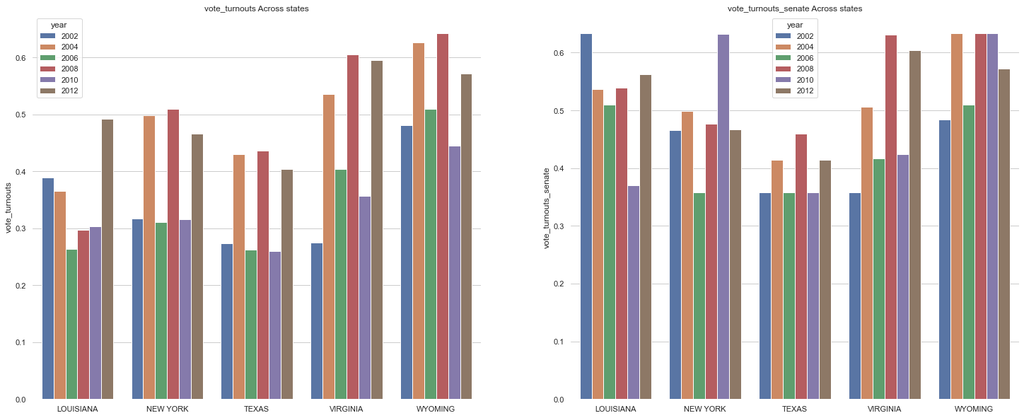

```python
plt.figure(figsize=(25, 10))
categorical_features = worst_States[['vote_turnouts','vote_turnouts_senate']]
for i in categorical_features:
    plt.subplot(1, 2, categorical_features.columns.get_loc(i)+1)
    sns.barplot(x='state',y=i,hue='year',data=worst_States)
    sns.despine(top=True, right=True, bottom=True, left=True)
    plt.tick_params(axis='both', which='both', bottom=False, top=False, left=False)
    plt.xlabel('')
    plt.title(i + ' Across states')
```

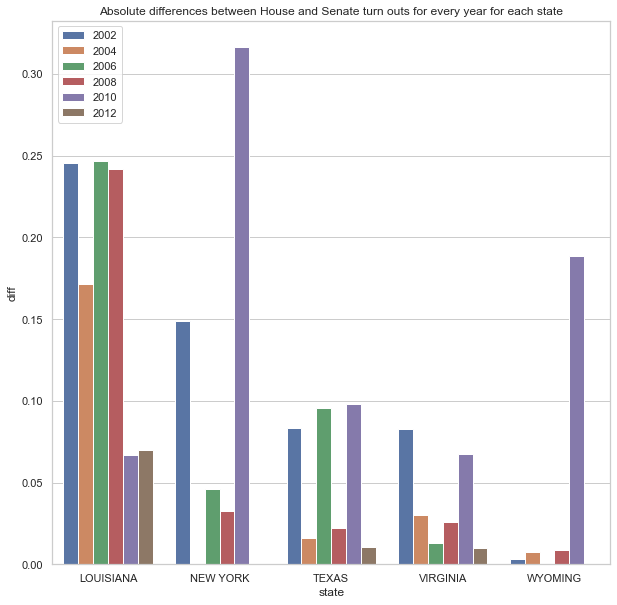

```python
worst_States['diff'] = worst_States['vote_turnouts'] - worst_States['vote_turnouts_senate']
worst_States['diff'] = np.absolute(worst_States['diff'])
plt.figure(figsize=(10, 10))
ax = sns.barplot(x="state", y="diff", hue="year", data=worst_States).set(title='Absolute differences between House and Senate turn outs for every year for each state')
plt.legend(loc='upper left')
```

#### Over sampling

As we saw above in the 5 states with the worst predictions something abnormal happens in 2010.  
Although Senate vote turnouts feature has high correlation of 0.8  
with our target, in 2010  
there is a high difference between the values of the House turn outs and the senate turn outs,  
which is the feature our models uses the most for the predicting, and therefore the predictions results for  
those states are the worst.  
Let's try duplicates samples with the same values of 2010 for Louisiana and Virginia and add them to our training  
dataframe so our model will be trained also on the abnormal samples, and therefore hopefully will produce  
better results for those states.

```python
over_sampling_df=sec_c_improvment.copy(deep = True)
```

```python
two_States_anomalies = sec_c_improvment.loc[(sec_c_improvment['year'] == 2010)&((sec_c_improvment['state'] == 'VIRGINIA') | (sec_c_improvment['state'] == 'LOUISIANA'))]
two_States_anomalies.drop('year',axis=1,inplace = False)
```

|  | state | special_x | party | writein | eligible_voters_2002 | eligible_voters_2004 | eligible_voters_2006 | eligible_voters_2008 | eligible_voters_2010 | eligible_voters_2012 | vote_turnouts | writein_president | party_president | vote_turnouts_president | special_y | writein_senate | party_senate | vote_turnouts_senate | year_presidential |
| --- | --- | --- | --- | --- | --- | --- | --- | --- | --- | --- | --- | --- | --- | --- | --- | --- | --- | --- | --- |
| 106 | LOUISIANA | 0.000 | R | 0.000 | 3407734.950 | 3442388.806 | 3478579.632 | 3516366.288 | 3415128.768 | 3467651.854 | 0.303 | 0.027 | 0.000 | 0.554 | 0.000 | 0.000 | 0.000 | 0.370 | 0 |
| 274 | VIRGINIA | 0.000 | R | 0.239 | 5526868.754 | 5604969.936 | 5686054.109 | 5770229.941 | 6142274.652 | 6288224.117 | 0.357 | 0.135 | 0.664 | 0.591 | 0.000 | 0.240 | 0.833 | 0.424 | 0 |

```python
#we set the year to 2009(which no elections from any type accrued) in order to distinguish those synthetic samples from the real train data
two_States_anomalies['year'] = 2009
duplicated_two_States_anomalies = two_States_anomalies.copy(deep=True)
duplicated_two_States_anomalies = duplicated_two_States_anomalies.append([two_States_anomalies] * 80)
duplicated_two_States_anomalies
```

|  | year | state | special_x | party | writein | eligible_voters_2002 | eligible_voters_2004 | eligible_voters_2006 | eligible_voters_2008 | eligible_voters_2010 | eligible_voters_2012 | vote_turnouts | writein_president | party_president | vote_turnouts_president | special_y | writein_senate | party_senate | vote_turnouts_senate | year_presidential |
| --- | --- | --- | --- | --- | --- | --- | --- | --- | --- | --- | --- | --- | --- | --- | --- | --- | --- | --- | --- | --- |
| 106 | 2009 | LOUISIANA | 0.000 | R | 0.000 | 3407734.950 | 3442388.806 | 3478579.632 | 3516366.288 | 3415128.768 | 3467651.854 | 0.303 | 0.027 | 0.000 | 0.554 | 0.000 | 0.000 | 0.000 | 0.370 | 0 |
| 274 | 2009 | VIRGINIA | 0.000 | R | 0.239 | 5526868.754 | 5604969.936 | 5686054.109 | 5770229.941 | 6142274.652 | 6288224.117 | 0.357 | 0.135 | 0.664 | 0.591 | 0.000 | 0.240 | 0.833 | 0.424 | 0 |
| 106 | 2009 | LOUISIANA | 0.000 | R | 0.000 | 3407734.950 | 3442388.806 | 3478579.632 | 3516366.288 | 3415128.768 | 3467651.854 | 0.303 | 0.027 | 0.000 | 0.554 | 0.000 | 0.000 | 0.000 | 0.370 | 0 |
| 274 | 2009 | VIRGINIA | 0.000 | R | 0.239 | 5526868.754 | 5604969.936 | 5686054.109 | 5770229.941 | 6142274.652 | 6288224.117 | 0.357 | 0.135 | 0.664 | 0.591 | 0.000 | 0.240 | 0.833 | 0.424 | 0 |
| 106 | 2009 | LOUISIANA | 0.000 | R | 0.000 | 3407734.950 | 3442388.806 | 3478579.632 | 3516366.288 | 3415128.768 | 3467651.854 | 0.303 | 0.027 | 0.000 | 0.554 | 0.000 | 0.000 | 0.000 | 0.370 | 0 |
| ... | ... | ... | ... | ... | ... | ... | ... | ... | ... | ... | ... | ... | ... | ... | ... | ... | ... | ... | ... | ... |
| 274 | 2009 | VIRGINIA | 0.000 | R | 0.239 | 5526868.754 | 5604969.936 | 5686054.109 | 5770229.941 | 6142274.652 | 6288224.117 | 0.357 | 0.135 | 0.664 | 0.591 | 0.000 | 0.240 | 0.833 | 0.424 | 0 |
| 106 | 2009 | LOUISIANA | 0.000 | R | 0.000 | 3407734.950 | 3442388.806 | 3478579.632 | 3516366.288 | 3415128.768 | 3467651.854 | 0.303 | 0.027 | 0.000 | 0.554 | 0.000 | 0.000 | 0.000 | 0.370 | 0 |
| 274 | 2009 | VIRGINIA | 0.000 | R | 0.239 | 5526868.754 | 5604969.936 | 5686054.109 | 5770229.941 | 6142274.652 | 6288224.117 | 0.357 | 0.135 | 0.664 | 0.591 | 0.000 | 0.240 | 0.833 | 0.424 | 0 |
| 106 | 2009 | LOUISIANA | 0.000 | R | 0.000 | 3407734.950 | 3442388.806 | 3478579.632 | 3516366.288 | 3415128.768 | 3467651.854 | 0.303 | 0.027 | 0.000 | 0.554 | 0.000 | 0.000 | 0.000 | 0.370 | 0 |
| 274 | 2009 | VIRGINIA | 0.000 | R | 0.239 | 5526868.754 | 5604969.936 | 5686054.109 | 5770229.941 | 6142274.652 | 6288224.117 | 0.357 | 0.135 | 0.664 | 0.591 | 0.000 | 0.240 | 0.833 | 0.424 | 0 |

162 rows × 20 columns

```python
#add the duplicated samples to the original dataset
over_sampling_df = over_sampling_df.append(duplicated_two_States_anomalies)
```

```python
over_sampling_df
```

|  | year | state | special_x | party | writein | eligible_voters_2002 | eligible_voters_2004 | eligible_voters_2006 | eligible_voters_2008 | eligible_voters_2010 | eligible_voters_2012 | vote_turnouts | writein_president | party_president | vote_turnouts_president | special_y | writein_senate | party_senate | vote_turnouts_senate | year_presidential |
| --- | --- | --- | --- | --- | --- | --- | --- | --- | --- | --- | --- | --- | --- | --- | --- | --- | --- | --- | --- | --- |
| 0 | 2002 | ALABAMA | 0.000 | R | 0.280 | 3407064.949 | 3421131.668 | 3436141.794 | 3452116.233 | 3647015.426 | 3673062.870 | 0.372 | 0.091 | 0.000 | 0.557 | 0.000 | 0.250 | 0.000 | 0.397 | 0 |
| 1 | 2004 | ALABAMA | 0.000 | R | 0.350 | 3407064.949 | 3421131.668 | 3436141.794 | 3452116.233 | 3647015.426 | 3673062.870 | 0.524 | 0.250 | 0.000 | 0.551 | 0.000 | 0.333 | 0.000 | 0.538 | 1 |
| 2 | 2006 | ALABAMA | 0.000 | R | 0.368 | 3407064.949 | 3421131.668 | 3436141.794 | 3452116.233 | 3647015.426 | 3673062.870 | 0.332 | 0.085 | 0.000 | 0.557 | 0.000 | 0.158 | 0.290 | 0.486 | 0 |
| 3 | 2008 | ALABAMA | 0.000 | R | 0.389 | 3407064.949 | 3421131.668 | 3436141.794 | 3452116.233 | 3647015.426 | 3673062.870 | 0.537 | 0.250 | 0.000 | 0.608 | 0.000 | 0.333 | 0.000 | 0.597 | 1 |
| 4 | 2010 | ALABAMA | 0.000 | R | 0.368 | 3407064.949 | 3421131.668 | 3436141.794 | 3452116.233 | 3647015.426 | 3673062.870 | 0.375 | 0.108 | 0.000 | 0.558 | 0.000 | 0.333 | 0.000 | 0.407 | 0 |
| ... | ... | ... | ... | ... | ... | ... | ... | ... | ... | ... | ... | ... | ... | ... | ... | ... | ... | ... | ... | ... |
| 274 | 2009 | VIRGINIA | 0.000 | R | 0.239 | 5526868.754 | 5604969.936 | 5686054.109 | 5770229.941 | 6142274.652 | 6288224.117 | 0.357 | 0.135 | 0.664 | 0.591 | 0.000 | 0.240 | 0.833 | 0.424 | 0 |
| 106 | 2009 | LOUISIANA | 0.000 | R | 0.000 | 3407734.950 | 3442388.806 | 3478579.632 | 3516366.288 | 3415128.768 | 3467651.854 | 0.303 | 0.027 | 0.000 | 0.554 | 0.000 | 0.000 | 0.000 | 0.370 | 0 |
| 274 | 2009 | VIRGINIA | 0.000 | R | 0.239 | 5526868.754 | 5604969.936 | 5686054.109 | 5770229.941 | 6142274.652 | 6288224.117 | 0.357 | 0.135 | 0.664 | 0.591 | 0.000 | 0.240 | 0.833 | 0.424 | 0 |
| 106 | 2009 | LOUISIANA | 0.000 | R | 0.000 | 3407734.950 | 3442388.806 | 3478579.632 | 3516366.288 | 3415128.768 | 3467651.854 | 0.303 | 0.027 | 0.000 | 0.554 | 0.000 | 0.000 | 0.000 | 0.370 | 0 |
| 274 | 2009 | VIRGINIA | 0.000 | R | 0.239 | 5526868.754 | 5604969.936 | 5686054.109 | 5770229.941 | 6142274.652 | 6288224.117 | 0.357 | 0.135 | 0.664 | 0.591 | 0.000 | 0.240 | 0.833 | 0.424 | 0 |

462 rows × 20 columns

```python
#seperte the data to train and test
sec_c_imp_train = over_sampling_df.loc[over_sampling_df['year'] < 2010]
sec_c_imp_test = over_sampling_df.loc[over_sampling_df['year'] >= 2010]

#define train dataset
sec_c_trainX = sec_c_imp_train.drop('vote_turnouts', inplace=False, axis=1)
sec_c_trainY = sec_c_imp_train['vote_turnouts']

#define test dataset
sec_c_testX = sec_c_imp_test.drop('vote_turnouts', inplace=False, axis=1)
states = sec_c_testX['state']
sec_c_testY = sec_c_imp_test['vote_turnouts']

#encoding categorical features
sec_c_trainX = encoding_features(sec_c_trainX, ['state', 'party'])
sec_c_testX = encoding_features(sec_c_testX, ['state', 'party'])

#running the adaboost mode;
ada_MSE, ada_R2, ada_gridsearch, Adaboost_predicted_vals = ada_boost(sec_c_trainX, sec_c_trainY, sec_c_testX,
                                                                     sec_c_testY)
```

```
sklearn Ada boost fit time 1.8270869255065918 seconds ---
                n_estimators
Selected Value            50
                     MSE   R^2
AdaBoost Regressor 0.001 0.861
```

As we can see we managed to overall improve the results of our model,  
we raised the R^2 from 0.817 to 0.861.  
Let's see if we also managed to improve Virginia and Louisiana predictions in a way that now they will be among  
the top 25.

```python
test = sec_c_imp_test.copy(deep=True)
#add predicted values column
test['predicted vals'] = Adaboost_predicted_vals
test
#grouping data by state
groupedby = test.groupby(['state'])

test_after_arrange = pd.DataFrame()
#calculating SSR for each state
for key, item in groupedby:
    state_samples = item
    state_samples = state_samples.assign(SSR=lambda x: (x['predicted vals'] - x['vote_turnouts']) ** 2)
    #summing the Squared error of each state of for both years
    state_samples['SSR'] = np.sum(state_samples['SSR'])
    test_after_arrange = test_after_arrange.append(state_samples.iloc[0:1, :])
```

```python
test_after_arrange.sort_values(ascending=False, by=['SSR'])[['state', 'SSR']].head()
```

|  | state | SSR |
| --- | --- | --- |
| 298 | WYOMING | 0.017 |
| 244 | SOUTH DAKOTA | 0.016 |
| 280 | WASHINGTON | 0.011 |
| 190 | NEW YORK | 0.009 |
| 256 | TEXAS | 0.006 |

As we can see Louisiana and Virginia are not among the worst 5 states, lets print a sorted par plot by SSR  
of the top 25 states.

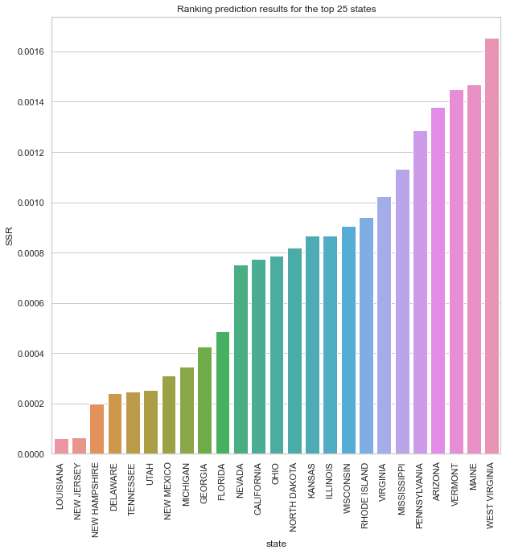

```python
# visualize the target variable
plt.figure(figsize=(10, 10))
ax = sns.barplot(x="state", y="SSR", data=test_after_arrange.sort_values(ascending=True, by=['SSR']).iloc[:25,:]).set(
    title='Ranking prediction results for the top 25 states')
plt.xticks(rotation=90)
plt.show()
```

As we can see we managed to improve Louisiana and Virginia predictions.  
Now Louisiana is ranked at the 1 place and Virginia at the 19 place among the top 25 states predictions.

### Section D - (Classification) house majority party predictions

### Task

Use the total votes counted by state in house elections cycle to create  
the label. If more votes were given to the democrat candidates in total, the state should be classified as D.  
Otherwise, if more votes were given to the republican candidates, the state should be categorized as R.  
Predict house majaority party in the 2010 and 2012 elections

### Checking different Models

### Classification Tree

```
building classify tree ended in 2.1552371978759766 seconds
                max_depth  min_samples_leaf  min_samples_split
Selected Value          4                15                  2
                          Accuracy
Decision Tree Classifier     0.730
```

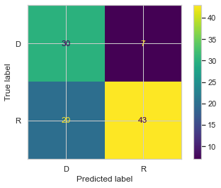

|  | sensitivity | specificity |
| --- | --- | --- |
| 0 | 0.811 | 0.683 |

```python
##sclearn implementation
dt = DecisionTreeClassifier(random_state=RSEED)
# define parameter grid
parameters_grid = {
    'max_depth': [2,4],
    'min_samples_leaf': [2,4,6,8,15,20],
    'min_samples_split': [2, 4, 8,30],
}

# define grid search
grid_search = GridSearchCV(estimator=dt, param_grid=parameters_grid, cv=10)

# fit estimator
start_time = time.time()
grid_search.fit(sec_d_trainX, sec_d_trainY)
print("building classify tree ended in %s seconds" % (time.time() - start_time))
# get best estimator
best = grid_search.best_estimator_

# print best parameters
print(pd.DataFrame.from_dict(grid_search.best_params_, orient='index', columns=['Selected Value']).T)
# predict
y_pred = best.predict(sec_d_testX)

#evaluating
# calculate accuracy
acc = round(accuracy_score(sec_d_testY, y_pred), 3)

df = pd.DataFrame([acc]).T
df = df.rename(index={0: 'Decision Tree Classifier'}, columns={0: 'Accuracy'})
df
print(df)

#confusion_matrix
plot_confusion_matrix(grid_search, sec_d_testX , sec_d_testY)
plt.show()

tp, fn, fp, tn = confusion_matrix(sec_d_testY, y_pred).ravel()
eval_Df = {"sensitivity": tp/(tp+fn), "specificity": tn/(tn+fp)}
pd.DataFrame(data=eval_Df, index=[0])
```

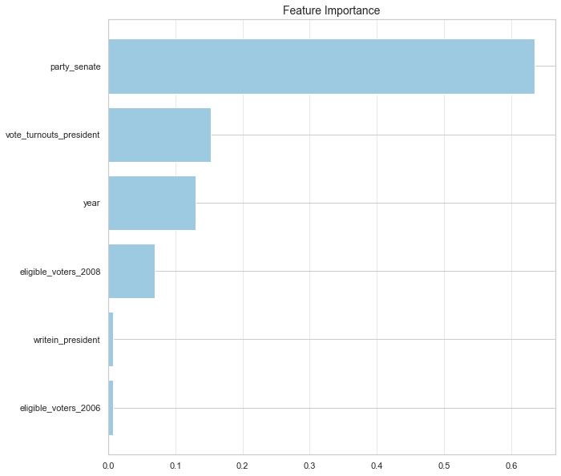

```python
#get feature importance
imp = pd.DataFrame(grid_search.best_estimator_.fit(sec_d_trainX, sec_d_trainY).feature_importances_,
                   index=sec_d_trainX.columns, columns=['Importance']).sort_values('Importance')
# plot feature importance
greater_then_0 = imp.loc[imp['Importance'] > 0]
# plot feature importance
plt.figure(figsize=(10, 10))
plt.barh(range(0, len(greater_then_0)), greater_then_0['Importance'], color='#9ecae1')
plt.grid(axis='x', alpha=0.5, color='lightgrey')
plt.yticks(range(0, len(greater_then_0)), greater_then_0.index)
plt.title('Feature Importance', fontsize=14)
plt.show()
```

### Ada Boost

```
building ada boost ended in 0.8001899719238281 seconds
                n_estimators
Selected Value            25
                     Accuracy
AdaBoost Classifier     0.770
```

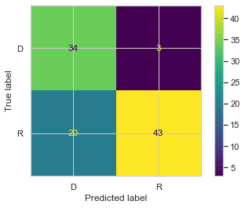

|  | sensitivity | specificity |
| --- | --- | --- |
| 0 | 0.919 | 0.683 |

```python
from sklearn.ensemble import AdaBoostClassifier

#Define the Model
# define model
ab = AdaBoostClassifier(random_state=RSEED)

# define parameter grid
parameters_grid = {
    'n_estimators': [30,25]
}

# define grid search
grid_search = GridSearchCV(estimator=ab, param_grid=parameters_grid, cv=10)

#Fit the Model
# fit estimator
start_time = time.time()
grid_search.fit(sec_d_trainX, sec_d_trainY)
print("building ada boost ended in %s seconds" % (time.time() - start_time))

# get best estimator
best = grid_search.best_estimator_
# print best parameters
print(pd.DataFrame.from_dict(grid_search.best_params_, orient='index', columns=['Selected Value']).T)

# predict
y_pred = best.predict(sec_d_testX)

#Evaluate the Model
# calculate accuracy
acc = round(accuracy_score(sec_d_testY, y_pred), 3)

df = pd.DataFrame([acc]).T
df = df.rename(index={0: 'AdaBoost Classifier'}, columns={0: 'Accuracy'})
print(df)

#confusion_matrix
plot_confusion_matrix(grid_search, sec_d_testX, sec_d_testY)
plt.show()

tp, fn, fp, tn = confusion_matrix(sec_d_testY, y_pred).ravel()
eval_Df = {"sensitivity": tp/(tp+fn), "specificity": tn/(tn+fp)}
pd.DataFrame(data=eval_Df, index=[0])
```

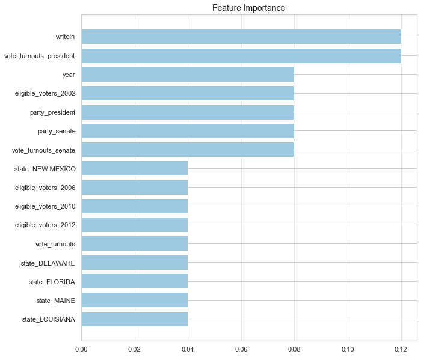

```python
#get feature importance
imp = pd.DataFrame(grid_search.best_estimator_.fit(sec_d_trainX, sec_d_trainY).feature_importances_,
                   index=sec_d_trainX.columns, columns=['Importance']).sort_values('Importance')
# plot feature importance
greater_then_0 = imp.loc[imp['Importance'] > 0]
# plot feature importance
plt.figure(figsize=(10, 10))
plt.barh(range(0, len(greater_then_0)), greater_then_0['Importance'], color='#9ecae1')
plt.grid(axis='x', alpha=0.5, color='lightgrey')
plt.yticks(range(0, len(greater_then_0)), greater_then_0.index)
plt.title('Feature Importance', fontsize=14)
plt.show()
```

#### KNN

```python
from sklearn.preprocessing import StandardScaler
sc = StandardScaler()
Xtrain_scaled = sc.fit_transform(sec_d_trainX)
Xtest_scaled = sc.fit_transform(sec_d_testX)
```

```
               n_neighbors   weights
Selected Value          40  distance
                Accuracy
KNN Classifier     0.840
```

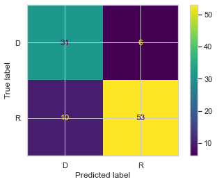

|  | sensitivity | specificity |
| --- | --- | --- |
| 0 | 0.838 | 0.841 |

```python
knn = KNeighborsClassifier()

# define parameter grid
parameters_grid = {
    'n_neighbors': [ 14, 15, 21,40],
    'weights': ['uniform', 'distance']
}

# define grid search
grid_search = GridSearchCV(estimator=knn, param_grid=parameters_grid, cv=10)


# fit estimator
grid_search.fit(Xtrain_scaled, sec_d_trainY)

# get best estimator
best = grid_search.best_estimator_

# print best parameters
print(pd.DataFrame.from_dict(grid_search.best_params_, orient='index', columns=['Selected Value']).T)


# predict
y_pred = best.predict(Xtest_scaled)


# calculate accuracy
acc = round(accuracy_score(sec_d_testY, y_pred), 3)

df = pd.DataFrame([acc]).T
df = df.rename(index={0: 'KNN Classifier'}, columns={0: 'Accuracy'})
print(df)

#confusion_matrix
plot_confusion_matrix(grid_search, Xtest_scaled, sec_d_testY)
plt.show()

tp, fn, fp, tn = confusion_matrix(sec_d_testY, y_pred).ravel()
eval_Df = {"sensitivity": tp/(tp+fn), "specificity": tn/(tn+fp)}
pd.DataFrame(data=eval_Df, index=[0])
```

#### Gradiant Boost

```
building gradient boost ended in 24.666076183319092 seconds
                learning_rate  max_depth  n_estimators
Selected Value          1.700      4.000        50.000
                              Accuracy
Gradient Boosting Classifier     0.810
```

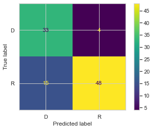

|  | sensitivity | specificity |
| --- | --- | --- |
| 0 | 0.892 | 0.762 |

```python
# define model
gb = GradientBoostingClassifier(random_state=RSEED)

# define parameter grid
parameters_grid = {
    'learning_rate': [0.5, 1, 1.5,1.7],
    'n_estimators': [50, 100,150],
    'max_depth':[2,3,4],
}

# define grid search
grid_search = GridSearchCV(estimator=gb, param_grid=parameters_grid, cv=10)

#Fit the Model
# fit estimator
start_time = time.time()
grid_search.fit(sec_d_trainX, sec_d_trainY)
print("building gradient boost ended in %s seconds" % (time.time() - start_time))

# get best estimator
best = grid_search.best_estimator_
# print best parameters
print(pd.DataFrame.from_dict(grid_search.best_params_, orient='index', columns=['Selected Value']).T)

#Predict
# predict
y_pred = best.predict(sec_d_testX)

#Evaluate the Model
# calculate accuracy
acc = round(accuracy_score(sec_d_testY, y_pred), 3)

df = pd.DataFrame([acc]).T
df = df.rename(index={0: 'Gradient Boosting Classifier'}, columns={0: 'Accuracy'})
print(df)

#confusion_matrix
plot_confusion_matrix(grid_search, sec_d_testX, sec_d_testY)
plt.show()

tp, fn, fp, tn = confusion_matrix(sec_d_testY, y_pred).ravel()
eval_Df = {"sensitivity": tp/(tp+fn), "specificity": tn/(tn+fp)}
pd.DataFrame(data=eval_Df, index=[0])
```

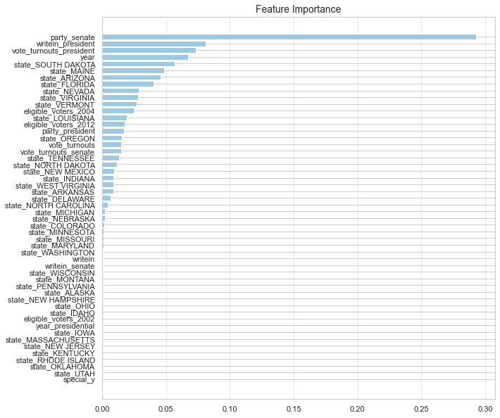

```python
#get feature importance
imp = pd.DataFrame(grid_search.best_estimator_.fit(sec_d_trainX, sec_d_trainY).feature_importances_,
                   index=sec_d_trainX.columns, columns=['Importance']).sort_values('Importance')
# plot feature importance
greater_then_0 = imp.loc[imp['Importance'] > 0]
# plot feature importance
plt.figure(figsize=(10, 10))
plt.barh(range(0, len(greater_then_0)), greater_then_0['Importance'], color='#9ecae1')
plt.grid(axis='x', alpha=0.5, color='lightgrey')
plt.yticks(range(0, len(greater_then_0)), greater_then_0.index)
plt.title('Feature Importance', fontsize=14)
plt.show()
```

#### Random Forest

```
building random forest ended in 35.97875952720642 seconds
                max_depth  min_samples_leaf  min_samples_split  n_estimators
Selected Value          3                 8                  2           100
                          Accuracy
Random Forest Classifier     0.780
```

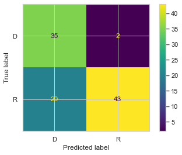

|  | sensitivity | specificity |
| --- | --- | --- |
| 0 | 0.946 | 0.683 |

```python
# define model
rf = RandomForestClassifier(random_state=RSEED)

# define parameter grid
parameters_grid = {
    'max_depth': [2, 3, 4],
    'min_samples_split': [2, 4, 8],
    'min_samples_leaf': [2, 8],
    'n_estimators': [50,70,100]
}

# define grid search
grid_search = GridSearchCV(estimator=rf, param_grid=parameters_grid, cv=10)

# fit estimator
start_time = time.time()
grid_search.fit(sec_d_trainX, sec_d_trainY)
print("building random forest ended in %s seconds" % (time.time() - start_time))

# get best estimator
best = grid_search.best_estimator_

# print best parameters
print(pd.DataFrame.from_dict(grid_search.best_params_, orient='index', columns=['Selected Value']).T)

# predict
y_pred = best.predict(sec_d_testX)

#Evaluate the Model
# calculate accuracy
acc = round(accuracy_score(sec_d_testY, y_pred), 3)

df = pd.DataFrame([acc]).T
df = df.rename(index={0: 'Random Forest Classifier'}, columns={0: 'Accuracy'})
print(df)

#confusion_matrix
plot_confusion_matrix(grid_search, sec_d_testX, sec_d_testY)
plt.show()

tp, fn, fp, tn = confusion_matrix(sec_d_testY, y_pred).ravel()
eval_Df = {"sensitivity": tp/(tp+fn), "specificity": tn/(tn+fp)}
pd.DataFrame(data=eval_Df, index=[0])
```

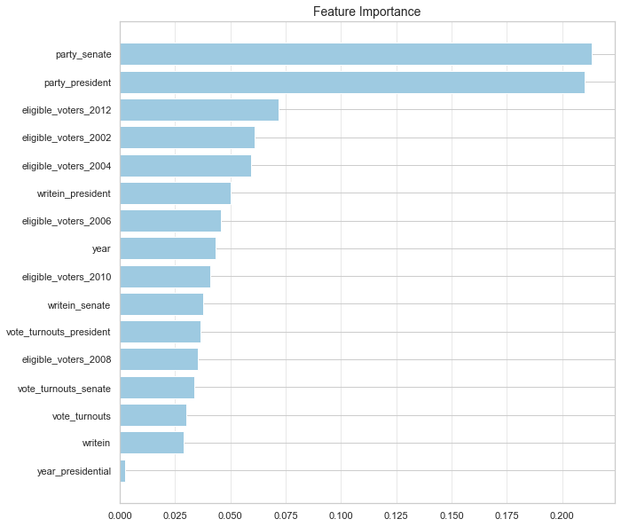

```python
#get feature importance
imp = pd.DataFrame(grid_search.best_estimator_.fit(sec_d_trainX, sec_d_trainY).feature_importances_,
                   index=sec_d_trainX.columns, columns=['Importance']).sort_values('Importance')
# plot feature importance
greater_then_0 = imp.loc[imp['Importance'] > 0]
# plot feature importance
plt.figure(figsize=(10, 10))
plt.barh(range(0, len(greater_then_0)), greater_then_0['Importance'], color='#9ecae1')
plt.grid(axis='x', alpha=0.5, color='lightgrey')
plt.yticks(range(0, len(greater_then_0)), greater_then_0.index)
plt.title('Feature Importance', fontsize=14)
plt.show()
```

#### SVM

```python
from sklearn import svm

# define model
clf = svm.SVC(random_state=RSEED)

# define parameter grid
parameters_grid = {
    'C': [0.1, 0.5,0.7,1.2,1.5,20,40,60],
    'kernel': ['linear', 'poly','rbf', 'sigmoid'],
    'degree': [3,4],

}

# define grid search
grid_search = GridSearchCV(estimator=clf, param_grid=parameters_grid, cv=10)

# fit estimator
grid_search.fit(Xtrain_scaled, sec_d_trainY)
# get best estimator
best = grid_search.best_estimator_

# print best parameters
print(pd.DataFrame.from_dict(grid_search.best_params_, orient='index', columns=['Selected Value']).T)

# predict
y_pred = best.predict(Xtest_scaled)

# calculate accuracy
SVM_acc = round(accuracy_score(sec_d_testY, y_pred), 3)
SVM_sensitivity, SVM_specificity = get_metrics(grid_search,sec_d_testY, y_pred)

df = pd.DataFrame([SVM_acc, SVM_sensitivity, SVM_specificity]).T
df = df.rename(index={0: 'SVM Classifier'}, columns={0: 'Accuracy', 1: 'Sensitivity', 2: 'Specificity'})
print(df)
```

```
                   C degree  kernel
Selected Value 0.100      3  linear
                Accuracy  Sensitivity  Specificity
SVM Classifier     0.810        0.865        0.778
```

#### Neural Network

```python
#X Y seperation
TRAINX = sect_d_train.drop('House_party',axis=1,inplace=False)
TRAINY = sect_d_train['House_party']
```

```python
#scaling X sets
sc = StandardScaler()
X_scaled = sc.fit_transform(TRAINX)
```

```python
mlp = MLPClassifier(hidden_layer_sizes=[40] *20, activation='identity', solver='adam', alpha=0.0001, batch_size='auto', learning_rate='invscaling', learning_rate_init=0.0001, power_t=0.05, max_iter=15000, shuffle=False, random_state=RSEED, tol=0.0001, verbose=False, warm_start=False, momentum=0.678, nesterovs_momentum=False,validation_fraction=0.3, beta_1=0.756, beta_2=0.567, epsilon=1e-008, max_fun=15000)
#fit the network
mlp.fit(X_scaled, TRAINY)
#train predict
predict_train = mlp.predict(X_scaled)
```

```python
#calculating and printing train accuracy, Sensitivity and specificity
train_acc = round(accuracy_score(TRAINY, predict_train), 3)
train_sensitivity, train_specificity = get_metrics(mlp,TRAINY, predict_train)

df = pd.DataFrame([train_acc, train_sensitivity, train_specificity]).T
df = df.rename(index={0: 'MLPClassifier Train:'}, columns={0: 'Accuracy', 1: 'Sensitivity', 2: 'Specificity'})
print(df)
```

```
                      Accuracy  Sensitivity  Specificity
MLPClassifier Train:     0.990        0.990        0.990
```

```python
#test predict
predict_test = mlp.predict(Xtest_scaled)
```

```python
#calculating and printing test accuracy, Sensitivity and specificity
test_acc = round(accuracy_score(sec_d_testY, predict_test), 3)
test_sensitivity, test_specificity = get_metrics(mlp,sec_d_testY, predict_test)

df = pd.DataFrame([test_acc, test_sensitivity, test_specificity]).T
df = df.rename(index={0: 'MLPClassifier Test:'}, columns={0: 'Accuracy', 1: 'Sensitivity', 2: 'Specificity'})
print(df)
```

```
                     Accuracy  Sensitivity  Specificity
MLPClassifier Test:     0.860        0.919        0.825
```

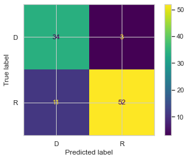

```python
plot_confusion_matrix(mlp, Xtest_scaled, sec_d_testY)
plt.show()
```

##### Now we will compare between the models results

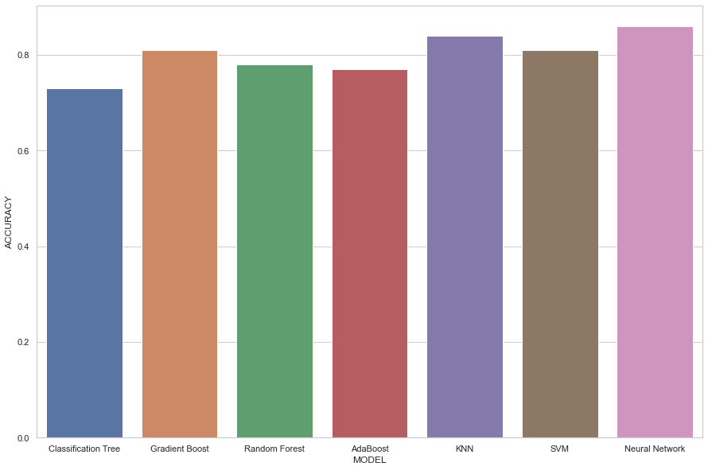

```python
ACCURACY_dict = {"ACCURACY": [0.73, 0.81, 0.78, 0.77, 0.84,0.81,0.86],
           "MODEL": ["Classification Tree", "Gradient Boost", "Random Forest", "AdaBoost","KNN","SVM","Neural Network"]}
ACCURACY = pd.DataFrame(ACCURACY_dict)
# visualize the target variable
plt.figure(figsize=(15, 10))
ax = sns.barplot(x="MODEL", y="ACCURACY", data=ACCURACY)
plt.show()
```

#### Summery

As we can see the Neural Network got the best accuracy score(0.86) after it  
is the KNN(0.84), and third are Gradient Boost along with the SVM(0.81), the most important feature in building the Gradient boost was:  
-party_Senate(the majority party in particular state in specific year in the Senate election).  
As, we saw that there is a pattern between the dominated parties in this elections and in the  
House elections.

### Section E - (Classification) Senate 2022 elections majority party predictions

### Task

Predict the outcome - Republican and Democrat Senator (independents count as democrats)  
of the 2022 midterm elections for each state.

### Checking different Models

#### Neural Network

```python
#scaling X sets
sc = StandardScaler()
X_scaled_train = sc.fit_transform(X_train_e)
X_scaled_test = sc.fit_transform(X_test_e)
```

```python
mlp = MLPClassifier(hidden_layer_sizes=[40] * 5, activation='identity', solver='adam', alpha=0.8, batch_size='auto',
                    learning_rate='adaptive', learning_rate_init=0.0001, power_t=0.05, max_iter=15000, shuffle=False,
                    random_state=RSEED, tol=0.0001, verbose=False, warm_start=False, momentum=0.678,
                    nesterovs_momentum=True, validation_fraction=0.3, beta_1=0.756, beta_2=0.567, epsilon=1e-008,
                    max_fun=15000)
#fit the network
mlp.fit(X_scaled_train, y_train_e)
```

```
MLPClassifier(activation='identity', alpha=0.8, beta_1=0.756, beta_2=0.567,
              hidden_layer_sizes=[40, 40, 40, 40, 40], learning_rate='adaptive',
              learning_rate_init=0.0001, max_iter=15000, momentum=0.678,
              power_t=0.05, random_state=10, shuffle=False,
              validation_fraction=0.3)
```

```python
#test predict
predict_test = mlp.predict(X_scaled_test)
#calculating and printing test accuracy, Sensitivity and specificity
test_acc = round(accuracy_score(y_test_e, predict_test), 3)
test_sensitivity, test_specificity = get_metrics(mlp, y_test_e, predict_test)

df = pd.DataFrame([test_acc, test_sensitivity, test_specificity]).T
df = df.rename(index={0: 'MLPClassifier Test:'}, columns={0: 'Accuracy', 1: 'Sensitivity', 2: 'Specificity'})
print(df)
```

```
                     Accuracy  Sensitivity  Specificity
MLPClassifier Test:     0.918        0.882        0.949
```

#### KNN

```python
knn = KNeighborsClassifier()

# define parameter grid
parameters_grid = {
    'n_neighbors': [7,14],
    'weights': ['uniform', 'distance']
}

# define grid search
grid_search = GridSearchCV(estimator=knn, param_grid=parameters_grid, cv=10)


# fit estimator
grid_search.fit(X_scaled_train, y_train_e)

# get best estimator
best = grid_search.best_estimator_

# print best parameters
print(pd.DataFrame.from_dict(grid_search.best_params_, orient='index', columns=['Selected Value']).T)


# predict
y_pred = best.predict(X_scaled_test)


# calculate accuracy
acc = round(accuracy_score(y_test_e, y_pred), 3)

df = pd.DataFrame([acc]).T
df = df.rename(index={0: 'KNN Classifier'}, columns={0: 'Accuracy'})
print(df)
```

```
               n_neighbors   weights
Selected Value           7  distance
                Accuracy
KNN Classifier     0.877
```

#### SVM

```python
from sklearn import svm

# define model
clf = svm.SVC(random_state=RSEED)

# define parameter grid
parameters_grid = {
    'C': [0.1, 0.5,0.7,1.2,1.5,20,40,60],
    'kernel': ['linear', 'poly','rbf', 'sigmoid'],
    'degree': [3,4],

}

# define grid search
grid_search = GridSearchCV(estimator=clf, param_grid=parameters_grid, cv=10)

# fit estimator
grid_search.fit(X_scaled_train, y_train_e)
# get best estimator
best = grid_search.best_estimator_

# print best parameters
print(pd.DataFrame.from_dict(grid_search.best_params_, orient='index', columns=['Selected Value']).T)

# predict
y_pred = best.predict(X_scaled_test)

# calculate accuracy
SVM_acc = round(accuracy_score(y_test_e, y_pred), 3)
SVM_sensitivity, SVM_specificity = get_metrics(grid_search,y_test_e, y_pred)

df = pd.DataFrame([SVM_acc, SVM_sensitivity, SVM_specificity]).T
df = df.rename(index={0: 'SVM Classifier'}, columns={0: 'Accuracy', 1: 'Sensitivity', 2: 'Specificity'})
print(df)
```

```
                   C degree kernel
Selected Value 1.500      3    rbf
                Accuracy  Sensitivity  Specificity
SVM Classifier     0.918        0.853        0.974
```

#### testing best model on estimated 2022 samples

As we saw all models gave similar good results, we will use the neural network to test its performance on the estimated 2022 samples.

```python
#scaling X sets
sc = StandardScaler()
X_scaled_2022 = sc.fit_transform(sec_e_2022X)
```

```python
#2022 predict
predict_2022 = mlp.predict(X_scaled_2022)
#calculating and printing test accuracy, Sensitivity and specificity
test_acc = round(accuracy_score(sec_e_2022Y, predict_2022), 3)
test_sensitivity, test_specificity = get_metrics(mlp, sec_e_2022Y, predict_2022)

df = pd.DataFrame([test_acc, test_sensitivity, test_specificity]).T
df = df.rename(index={0: 'MLPClassifier 2022 Senate elections:'}, columns={0: 'Accuracy', 1: 'Sensitivity', 2: 'Specificity'})
print(df)
```

```
                                      Accuracy  Sensitivity  Specificity
MLPClassifier 2022 Senate elections:     0.970        1.000        0.952
```

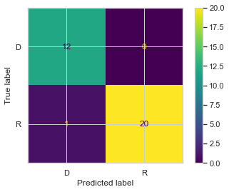

```python
plot_confusion_matrix(mlp, X_scaled_2022, sec_e_2022Y)
plt.show()
```

#### Summery

Our Neural network predicted the estimated results with accuracy of 97%, and actual past results with accuracy of 91.8%  
Near to the elections in November when the required X features will be available, another more accurate predicting  
will be possible to apply.  
Now lets see that will be the parties ratio after the elections according to the model.

##### Elections Results for each states according to the model

```python
predictions = pd.DataFrame()
predictions['State'] = sec_e_2022_states
predictions['Majority_party'] = predict_2022
predictions
```

|  | State | Majority_party |
| --- | --- | --- |
| 0 | ALABAMA | R |
| 11 | ALASKA | R |
| 22 | ARIZONA | R |
| 33 | ARKANSAS | R |
| 44 | CALIFORNIA | D |
| 55 | CONNECTICUT | D |
| 66 | FLORIDA | R |
| 77 | GEORGIA | R |
| 88 | HAWAII | D |
| 99 | IDAHO | R |
| 110 | ILLINOIS | D |
| 121 | INDIANA | R |
| 132 | IOWA | D |
| 143 | KANSAS | R |
| 154 | KENTUCKY | R |
| 165 | LOUISIANA | R |
| 176 | MARYLAND | D |
| 187 | MISSOURI | R |
| 198 | NEVADA | D |
| 209 | NEW HAMPSHIRE | D |
| 220 | NEW YORK | D |
| 231 | NORTH CAROLINA | R |
| 242 | NORTH DAKOTA | D |
| 253 | OHIO | R |
| 264 | OKLAHOMA | R |
| 275 | OREGON | D |
| 286 | PENNSYLVANIA | R |
| 297 | SOUTH CAROLINA | R |
| 308 | SOUTH DAKOTA | R |
| 319 | UTAH | R |
| 330 | VERMONT | R |
| 341 | WASHINGTON | D |
| 352 | WISCONSIN | D |

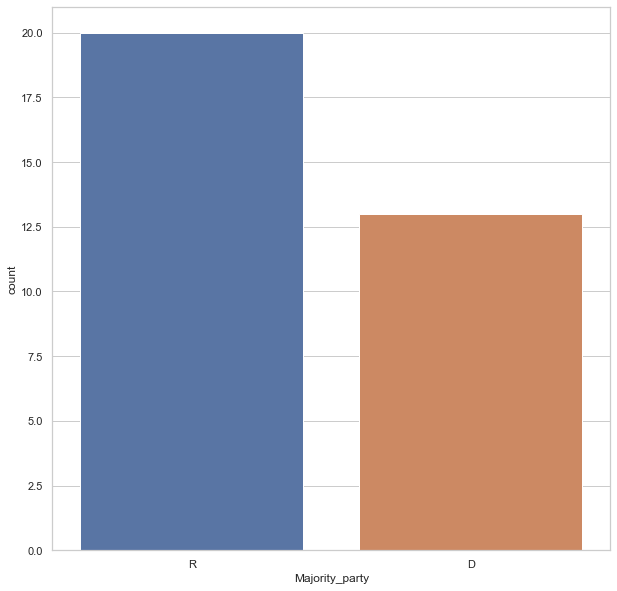

```python
# visualize the label variable
plt.figure(figsize=(10, 10))
g = sns.countplot(predictions['Majority_party'])
g.set_xticklabels(['R','D'])
plt.show()
```

```python
len(predictions.loc[predictions['Majority_party']=='R'])/len(predictions.loc[predictions['Majority_party']=='D'])
```

```
1.5384615384615385
```

As we can see according to our model and the estimated X features,  
about 53% more Republicans will be elected than Democrats.

##### The ratio of the parties after the elections

According to current ratio of the parties (data was taken from [official senate site](https://www.senate.gov/senators/index.htm)),  
we will estimate the ratio of the parties after the elections.

```python
# import dataset
senate_2020_df = pd.read_excel('data/USElectionResults19762020/Senate_2020.xlsx')
```

```python
senate_2020_df
```

|  | state | party |
| --- | --- | --- |
| 0 | Alabama | Republican |
| 1 | Alabama | Republican |
| 2 | Alaska | Republican |
| 3 | Alaska | Republican |
| 4 | Arizona | Democratic |
| ... | ... | ... |
| 95 | West Virginia | Democratic |
| 96 | Wisconsin | Democratic |
| 97 | Wisconsin | Republican |
| 98 | Wyoming | Republican |
| 99 | Wyoming | Republican |

100 rows × 2 columns

```python
#grouping counties by state
merged_senate2020_df_groupedby = senate_2020_df.groupby(['state'])

merged_senate2020_df_after_arrange = pd.DataFrame()
#caluctaing the number of Republicans and Democrats representatives in each state today
for key,item in merged_senate2020_df_groupedby:
    counties_per_state = item
    counties_per_state['R'] = len(counties_per_state.loc[counties_per_state['party'] == 'Republican'])
    counties_per_state['D'] = len(counties_per_state.loc[(counties_per_state['party'] == 'Democratic') | (counties_per_state['party'] == 'Independent')])
    merged_senate2020_df_after_arrange = merged_senate2020_df_after_arrange.append(counties_per_state.iloc[0:1,:])
merged_senate2020_df_after_arrange.drop('party',axis=1,inplace=True)
```

```python
merged_senate2020_df_after_arrange
```

|  | state | R | D |
| --- | --- | --- | --- |
| 0 | Alabama | 2 | 0 |
| 2 | Alaska | 2 | 0 |
| 4 | Arizona | 0 | 2 |
| 6 | Arkansas | 2 | 0 |
| 8 | California | 0 | 2 |
| 10 | Colorado | 0 | 2 |
| 12 | Connecticut | 0 | 2 |
| 14 | Delaware | 0 | 2 |
| 16 | Florida | 2 | 0 |
| 18 | Georgia | 0 | 2 |
| 20 | Hawaii | 0 | 2 |
| 22 | Idaho | 2 | 0 |
| 24 | Illinois | 0 | 2 |
| 26 | Indiana | 2 | 0 |
| 28 | Iowa | 2 | 0 |
| 30 | Kansas | 2 | 0 |
| 32 | Kentucky | 2 | 0 |
| 34 | Louisiana | 2 | 0 |
| 36 | Maine | 1 | 1 |
| 38 | Maryland | 0 | 2 |
| 40 | Massachusetts | 0 | 2 |
| 42 | Michigan | 0 | 2 |
| 44 | Minnesota | 0 | 2 |
| 46 | Mississippi | 2 | 0 |
| 48 | Missouri | 2 | 0 |
| 50 | Montana | 1 | 1 |
| 52 | Nebraska | 2 | 0 |
| 54 | Nevada | 0 | 2 |
| 56 | New Hampshire | 0 | 2 |
| 58 | New Jersey | 0 | 2 |
| 60 | New Mexico | 0 | 2 |
| 62 | New York | 0 | 2 |
| 64 | North Carolina | 2 | 0 |
| 66 | North Dakota | 2 | 0 |
| 68 | Ohio | 1 | 1 |
| 70 | Oklahoma | 2 | 0 |
| 72 | Oregon | 0 | 2 |
| 74 | Pennsylvania | 1 | 1 |
| 76 | Rhode Island | 0 | 2 |
| 78 | South Carolina | 2 | 0 |
| 80 | South Dakota | 2 | 0 |
| 82 | Tennessee | 2 | 0 |
| 84 | Texas | 2 | 0 |
| 86 | Utah | 2 | 0 |
| 88 | Vermont | 0 | 2 |
| 90 | Virginia | 0 | 2 |
| 92 | Washington | 0 | 2 |
| 94 | West Virginia | 1 | 1 |
| 96 | Wisconsin | 1 | 1 |
| 98 | Wyoming | 2 | 0 |

Current Status

```python
print("Total Republican Senators in 2020 before the elections:",merged_senate2020_df_after_arrange['R'].sum())
print("Total Democratic Senators in 2020 before the elections:",merged_senate2020_df_after_arrange['D'].sum())
```

```
Total Republican Senators in 2020 before the elections: 50
Total Democratic Senators in 2020 before the elections: 50
```

```python
mask = merged_senate2020_df_after_arrange['state'].isin(relevant_states)
relevant_states_senate_2020 = merged_senate2020_df_after_arrange[mask]
print("Elections states Republican Senators in 2020 before the elections:",relevant_states_senate_2020['R'].sum())
print("Elections states Democratic Senators in 2020 before the elections:",relevant_states_senate_2020['D'].sum())
```

```
Elections states Republican Senators in 2020 before the elections: 37
Elections states Democratic Senators in 2020 before the elections: 29
```

predicted results

```python
print("Elections states Republican senators 2022 predicitons",len(predictions.loc[predictions['Majority_party']=='R']))
print("Elections states Democratic senators 2022 predicitons",len(predictions.loc[predictions['Majority_party']=='D']))
```

```
Elections states Republican senators 2022 predicitons 20
Elections states Democratic senators 2022 predicitons 13
```

Updating according to the predicitons

```python
#change state to uppercase for merging
relevant_states_senate_2020['state'] =  relevant_states_senate_2020['state'].str.upper()
```

```python
#merging the predictions df with the party representatives df of the relevant states for 2022 elections
relevant_states_senate_2022 = pd.merge(relevant_states_senate_2020,predictions, how='inner', left_on=['state'], right_on = ['State'])
```

```python
relevant_states_senate_2022.drop('State',axis=1,inplace=True)
relevant_states_senate_2022
```

|  | state | R | D | Majority_party |
| --- | --- | --- | --- | --- |
| 0 | ALABAMA | 2 | 0 | R |
| 1 | ALASKA | 2 | 0 | R |
| 2 | ARIZONA | 0 | 2 | R |
| 3 | ARKANSAS | 2 | 0 | R |
| 4 | CALIFORNIA | 0 | 2 | D |
| 5 | CONNECTICUT | 0 | 2 | D |
| 6 | FLORIDA | 2 | 0 | R |
| 7 | GEORGIA | 0 | 2 | R |
| 8 | HAWAII | 0 | 2 | D |
| 9 | IDAHO | 2 | 0 | R |
| 10 | ILLINOIS | 0 | 2 | D |
| 11 | INDIANA | 2 | 0 | R |
| 12 | IOWA | 2 | 0 | D |
| 13 | KANSAS | 2 | 0 | R |
| 14 | KENTUCKY | 2 | 0 | R |
| 15 | LOUISIANA | 2 | 0 | R |
| 16 | MARYLAND | 0 | 2 | D |
| 17 | MISSOURI | 2 | 0 | R |
| 18 | NEVADA | 0 | 2 | D |
| 19 | NEW HAMPSHIRE | 0 | 2 | D |
| 20 | NEW YORK | 0 | 2 | D |
| 21 | NORTH CAROLINA | 2 | 0 | R |
| 22 | NORTH DAKOTA | 2 | 0 | D |
| 23 | OHIO | 1 | 1 | R |
| 24 | OKLAHOMA | 2 | 0 | R |
| 25 | OREGON | 0 | 2 | D |
| 26 | PENNSYLVANIA | 1 | 1 | R |
| 27 | SOUTH CAROLINA | 2 | 0 | R |
| 28 | SOUTH DAKOTA | 2 | 0 | R |
| 29 | UTAH | 2 | 0 | R |
| 30 | VERMONT | 0 | 2 | R |
| 31 | WASHINGTON | 0 | 2 | D |
| 32 | WISCONSIN | 1 | 1 | D |

```python
#calculating the representatives status after the results in the relevant states
for i in range(0,33):
    if relevant_states_senate_2022.iloc[i]['Majority_party'] == 'R' and relevant_states_senate_2022.iloc[i]['R'] < 2:
        relevant_states_senate_2022.iat[i,1] = relevant_states_senate_2022.iloc[i]['R'] + 1
        relevant_states_senate_2022.iat[i,2] = relevant_states_senate_2022.iloc[i]['D'] - 1
    elif relevant_states_senate_2022.iloc[i]['Majority_party'] == 'D' and relevant_states_senate_2022.iloc[i]['D'] < 2:
        relevant_states_senate_2022.iat[i,1] = relevant_states_senate_2022.iloc[i]['R'] - 1
        relevant_states_senate_2022.iat[i,2] = relevant_states_senate_2022.iloc[i]['D'] + 1
relevant_states_senate_2022
```

|  | state | R | D | Majority_party |
| --- | --- | --- | --- | --- |
| 0 | ALABAMA | 2 | 0 | R |
| 1 | ALASKA | 2 | 0 | R |
| 2 | ARIZONA | 1 | 1 | R |
| 3 | ARKANSAS | 2 | 0 | R |
| 4 | CALIFORNIA | 0 | 2 | D |
| 5 | CONNECTICUT | 0 | 2 | D |
| 6 | FLORIDA | 2 | 0 | R |
| 7 | GEORGIA | 1 | 1 | R |
| 8 | HAWAII | 0 | 2 | D |
| 9 | IDAHO | 2 | 0 | R |
| 10 | ILLINOIS | 0 | 2 | D |
| 11 | INDIANA | 2 | 0 | R |
| 12 | IOWA | 1 | 1 | D |
| 13 | KANSAS | 2 | 0 | R |
| 14 | KENTUCKY | 2 | 0 | R |
| 15 | LOUISIANA | 2 | 0 | R |
| 16 | MARYLAND | 0 | 2 | D |
| 17 | MISSOURI | 2 | 0 | R |
| 18 | NEVADA | 0 | 2 | D |
| 19 | NEW HAMPSHIRE | 0 | 2 | D |
| 20 | NEW YORK | 0 | 2 | D |
| 21 | NORTH CAROLINA | 2 | 0 | R |
| 22 | NORTH DAKOTA | 1 | 1 | D |
| 23 | OHIO | 2 | 0 | R |
| 24 | OKLAHOMA | 2 | 0 | R |
| 25 | OREGON | 0 | 2 | D |
| 26 | PENNSYLVANIA | 2 | 0 | R |
| 27 | SOUTH CAROLINA | 2 | 0 | R |
| 28 | SOUTH DAKOTA | 2 | 0 | R |
| 29 | UTAH | 2 | 0 | R |
| 30 | VERMONT | 1 | 1 | R |
| 31 | WASHINGTON | 0 | 2 | D |
| 32 | WISCONSIN | 0 | 2 | D |

```python
print("Elections states Republican senators 2022 after elections",relevant_states_senate_2022['R'].sum())
print("Elections states Democratic senators 2022 after elections",relevant_states_senate_2022['D'].sum())
```

```
Elections states Republican senators 2022 after elections 39
Elections states Democratic senators 2022 after elections 27
```

```python
print("Total Republican senators 2022 after elections",39+13)
print("Total Democratic senators 2022 after elections",27+21)
```

```
Total Republican senators 2022 after elections 52
Total Democratic senators 2022 after elections 48
```

##### Outcome

After adding the senate representatives from states that don't participate in the elections(21 D, 13 R)  
we get that in total the Democrats will get 48 representatives and the Republicans 52,  
which means that the tie will be broken!

##### Saving the model for future predicting

```python
# Save the model as a pickle in a file
joblib.dump(mlp, 'Senate_majority_party_predictor.pkl')
```

```
['Senate_majority_party_predictor.pkl']
```

```python
# Load the model from the file
mlp_from_joblib = joblib.load('Senate_majority_party_predictor.pkl')
```